# Mental Health Outcomes in Gamers

Team 5 – DATS 6101

2024-12-09

```r
df <- read.csv("GamingStudy_data.csv")
```

# Introduction

This report is follow-up of Team 5’s earlier exploration into the effects of video game habits on mental health. Previous analysis through hypothesis tests revealed:

- Hours spent playing video games affects how much time is spent streaming
- There is a significant affect on hours played and mental health outomes
- Gamers who play for “fun” have better mental health outcomes; those who play for “winning” and “escaping” do not.

### Reasearch Proposal

Use regressor and classification model to predict mental health outcomes based on gaming habits and certain demographic information. When possible, inference which variables contribute the most.

### The Data

This data set (https://www.kaggle.com/datasets/divyansh22/online-gaming-anxiety-data/data) surveyed 13,464 gamers and had them answer questions not only about time spent playing video games, but it also asked questions that are typically seen in psychological diagnosis tests approved in the Diagnostic and Statistical Manual of Mental Disorders (DSM) (**marian_sauter_gaming_2017?**). Please note that the terms gamers and surveyors will be used interchangeably in this report.

### Mental Health Inventories and Predictors

This is the list of mental health indicators.

1. GAD-7 (Generalized Anxiety Disorder, 7 questions)
2. GADE (Generalized Anxiety Disorder, Effect in Life)
3. SWL (Satisfaction with Life)
4. SPIN (Social Phobia Inventories)

This is the list of mental health predictors.

1. Hours: the hours per week playing video games
2. Streams: the hours per week spent streaming video games
3. whyplay: the reason why surveyors play video games
4. Age: the number of years a surveyor is when the survey was completed
5. Gender: the sex of surverors
6. Game Played: the selected game surveyors play the most

# Exploratory Data Analysis (EDA)

Before examaing out models, an abridged reminded of our EDA highlights is needed.

### Assumption of Continuity

In our EDA, we noticed that the data for the psychological inventories was not truly continuous. This was made apparent when attempting logarithmic and scale transformations. However, due to the level of difficulty this course is expecting us to persevere, we are assuming normality for all variables.

### Demographics

First, we need to examine the demographics of surveyors. Since we have age, gender, country of residence, and game played, let’s see what we can find out.

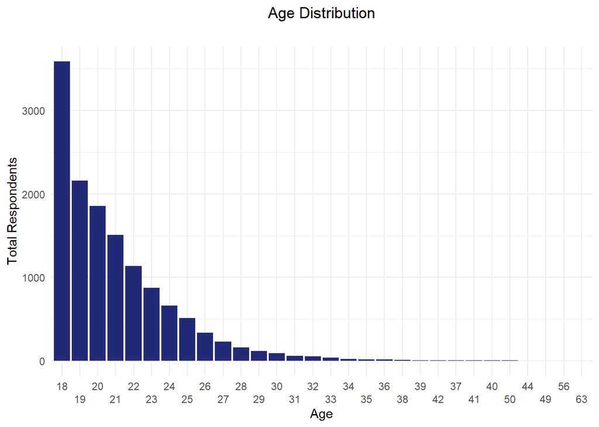

```r
age_counts <- as.data.frame(table(df$Age))
colnames(age_counts) <- c("Age", "SurveyCount")
age_counts <- age_counts[order(-age_counts$SurveyCount), ]

# Create the plot
fig <- ggplot(age_counts, aes(x = reorder(Age, -SurveyCount), y = SurveyCount)) +
  geom_bar(stat = 'identity', fill = '#232A75') +
  labs(title = 'Age Distribution',
       subtitle = '',
       x = 'Age',
       y = 'Total Respondents') +
  scale_x_discrete(guide = guide_axis(n.dodge = 2)) +
  theme_minimal()  +
 theme(plot.title = element_text(hjust = 0.5))

# Print the figure
print(fig)
```

The age histogram tells us that gamers who are 18 years old make up most of the surveyors, followed by 19 and 20 year old gamers. This means age is extremely right skewed.

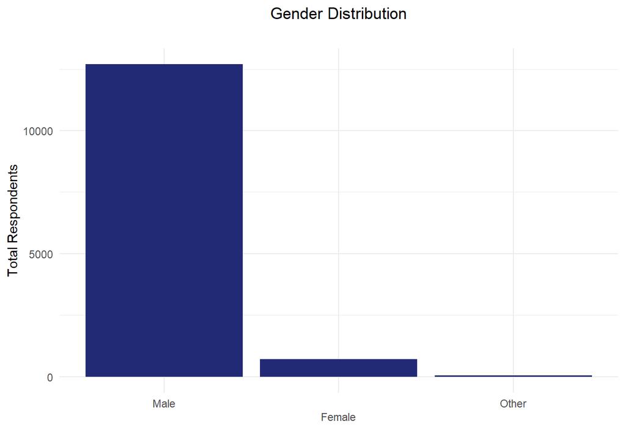

```r
gender_counts <- as.data.frame(table(df$Gender))
colnames(gender_counts) <- c("Gender", "SurveyCount")
gender_counts <- gender_counts[order(-gender_counts$SurveyCount), ]

# Create the plot
fig <- ggplot(gender_counts, aes(x = reorder(Gender, -SurveyCount), y = SurveyCount)) +
  geom_bar(stat = 'identity', fill = '#232A75') +
  labs(title = 'Gender Distribution',
       subtitle = '',
       x = '',
       y = 'Total Respondents') +
  scale_x_discrete(guide = guide_axis(n.dodge = 2)) +
  theme_minimal()  +
 theme(plot.title = element_text(hjust = 0.5))

# Print the figure
print(fig)
```

The respondents/surveyors are almost entirely males. This is another, significant right-skewed variable.

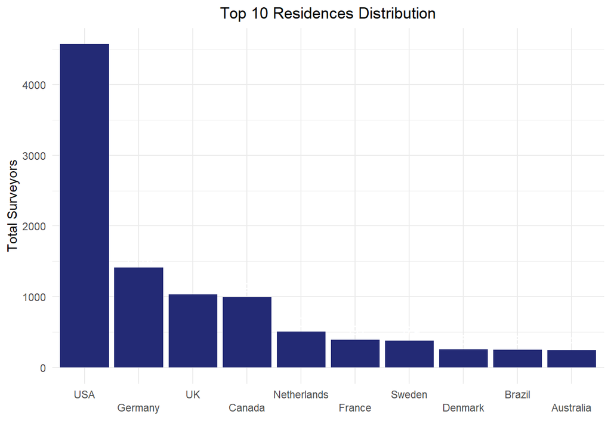

```r
Residence_counts <- as.data.frame(table(df$Residence))
colnames(Residence_counts) <- c("Residence", "SurveyCount")
Residence_counts <- Residence_counts[order(-Residence_counts$SurveyCount), ]

# Keep only the top 10 residences
top_10_residences <- head(Residence_counts, 10)

# Create the plot
fig <- ggplot(top_10_residences, aes(x = reorder(Residence, -SurveyCount), y = SurveyCount)) +
  geom_bar(stat = 'identity', fill = '#232A75') +
  geom_text(aes(label = SurveyCount), vjust = -0.5, color = 'white') +
  labs(title = 'Top 10 Residences Distribution',
       x = '',
       y = 'Total Surveyors') +
  scale_x_discrete(guide = guide_axis(n.dodge = 2)) +
  theme_minimal() +
  theme(plot.title = element_text(hjust = 0.5))

# Print the figure
print(fig)
```

Interestingly, we see that most of the surveyors reside in the United States of America. Since there were a lot of countries available for selection in the survey, we limited the histogram to only show the top 10 countries.

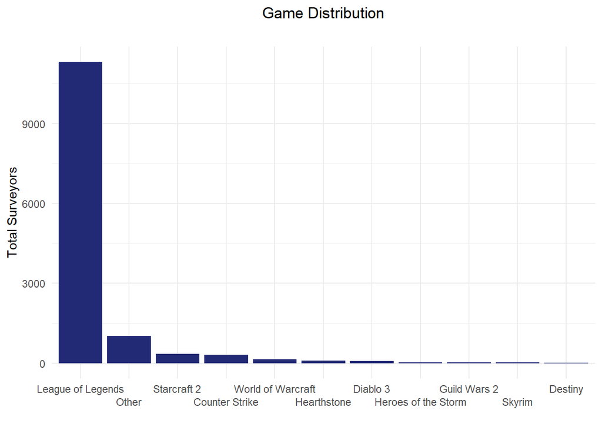

```r
game_counts <- as.data.frame(table(df$Game))
colnames(game_counts) <- c("Game", "SurveyCount")
game_counts <- game_counts[order(-game_counts$SurveyCount), ]

# Create the plot
fig <- ggplot(game_counts, aes(x = reorder(Game, -SurveyCount), y = SurveyCount)) +
  geom_bar(stat = 'identity', fill = '#232A75') +
  labs(title = 'Game Distribution',
       subtitle = '',
       x = '',
       y = 'Total Surveyors') +
  scale_x_discrete(guide = guide_axis(n.dodge = 2)) +
  theme_minimal()  +
 theme(plot.title = element_text(hjust = 0.5))
# Print the figure
print(fig)
```

Finally, we see that the game most played is League of Legends, a multi-player battle arena video game. While this also makes this variable right-skewed, it also informs us that the data analyzed for this project is applicable primarily for gamers who engage in multi-player/online mediums. League of Legends happens to be the best represented in our data.

To summarize the demographics of our data, we are mostly looking at 18 year old males that reside in the United States and play League of Legends.

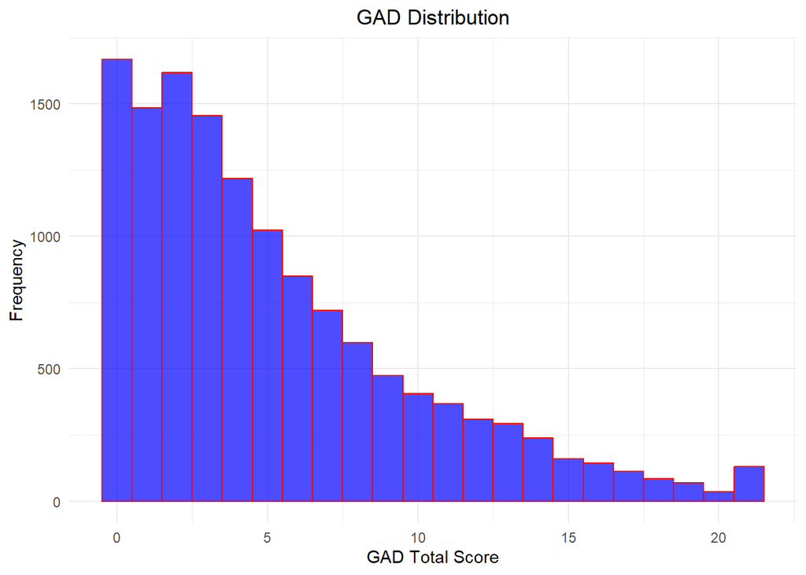

```r
ggplot(data = df, aes(x = GAD_T)) +
  geom_histogram(binwidth = 1,
                 color = "red",
                 fill = "blue",
                 alpha = .7) + # opacity
  labs(x = "GAD Total Score", y = "Frequency", title = "GAD Distribution") +
  theme_minimal() +
  theme(plot.title = element_text(hjust = 0.5))
```

### Ordinal for Psychological Inventories

Given that our most import dependent variables (GAD_T, SWL_T, SPIN_T) are discrete counts of scores rather than continious numbers, we covert the scores to ordinal factors based on clinical definitions. (**greenspace_mental_health_social_2020?**; **yun_satisfaction_2019?**; **sapra_using_2020?**).

```r
# Function to convert GAD_T to ordinal variable
convert_GAD <- function(score) {
  if (is.na(score)) return(NA)  # Handle NA values
  if (score >= 0 & score <= 4) {
    return("minimal anxiety")
  } else if (score >= 5 & score <= 9) {
    return("mild anxiety")
  } else if (score >= 10 & score <= 14) {
    return("moderate anxiety")
  } else if (score >= 15 & score <= 21) {
    return("severe anxiety")
  } else {
    return(NA)  # Handles scores outside defined range
  }
}

# Function to convert SWL_T to ordinal variable
convert_SWL <- function(score) {
  if (is.na(score)) return(NA)  # Handle NA values
  if (score >= 31 & score <= 35) {
    return("extremely satisfied")
  } else if (score >= 26 & score <= 30) {
    return("satisfied")
  } else if (score >= 21 & score <= 25) {
    return("slightly satisfied")
  } else if (score == 20) {
    return("neutral")
  } else if (score >= 15 & score <= 19) {
    return("slightly dissatisfied")
  } else if (score >= 10 & score <= 14) {
    return("dissatisfied")
  } else if (score >= 5 & score <= 9) {
    return("extremely dissatisfied")
  } else {
    return(NA)  # Handles scores outside defined range
  }
}

# Function to convert SPIN_T to ordinal variable
convert_SPIN <- function(score) {
  if (is.na(score)) return(NA)  # Handle NA values
  if (score >= 0 & score <= 20) {
    return("none")
  } else if (score >= 21 & score <= 30) {
    return("mild")
  } else if (score >= 31 & score <= 40) {
    return("moderate")
  } else if (score >= 41 & score <= 50) {
    return("severe")
  } else if (score >= 51 & score <= 68) {
    return("very severe")
  } else {
    return(NA)  # Handles scores outside defined range
  }
}

# Function to convert hours to ordinal variable
convert_hours <- function(hours) {
  if (is.na(hours)) return(NA)  # Handle NA values
  if (hours >= 0 & hours <= 10) {
    return("Low")
  } else if (hours > 10 & hours <= 20) {
    return("Moderate")
  } else if (hours > 20 & hours <= 30) {
    return("High")
  } else if (hours > 30) {
    return("Very High")
  } else {
    return(NA)  # Handles any unexpected values
  }
}

# Create new columns in the data frame
df$GAD_ord <- sapply(df$GAD_T, convert_GAD)
df$SWL_ord <- sapply(df$SWL_T, convert_SWL)
df$SPIN_ord <- sapply(df$SPIN_T, convert_SPIN)
df$hours_ord <- sapply(df$Hours, convert_hours)


#make values ordinal (min to max)
df$GAD_ord <- factor(df$GAD_ord,
                     levels = c("minimal anxiety", "mild anxiety", "moderate anxiety", "severe anxiety"),
                     ordered = TRUE)

df$SWL_ord <- factor(df$SWL_ord,
                     levels = c("extremely satisfied", "satisfied", "slightly satisfied", "neutral",
                                "slightly dissatisfied", "dissatisfied", "extremely dissatisfied"),
                     ordered = TRUE)

df$SPIN_ord <- factor(df$SPIN_ord,
                      levels = c("none", "mild", "moderate", "severe", "very severe"),
                      ordered = TRUE)

df$hours_ord <- factor(df$hours_ord,
                            levels = c("Low", "Moderate", "High", "Very High"),
                            ordered = TRUE)


# Print the updated data frame
#print(df$GAD_ord)
```

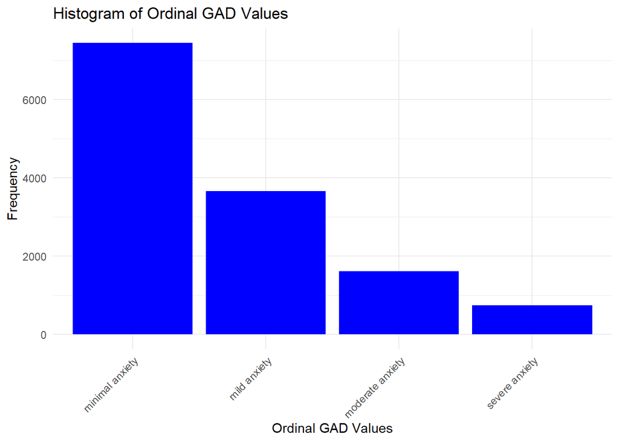

```r
ggplot(df, aes(x = GAD_ord)) +
  geom_bar(fill = "blue") +
  labs(title = "Histogram of Ordinal GAD Values",
       x = "Ordinal GAD Values",
       y = "Frequency") +
  theme_minimal() +
  theme(axis.text.x = element_text(angle = 45, hjust = 1))
```

GAD has been converted into four classes, with the “minimal anxiety” class having the most observations.

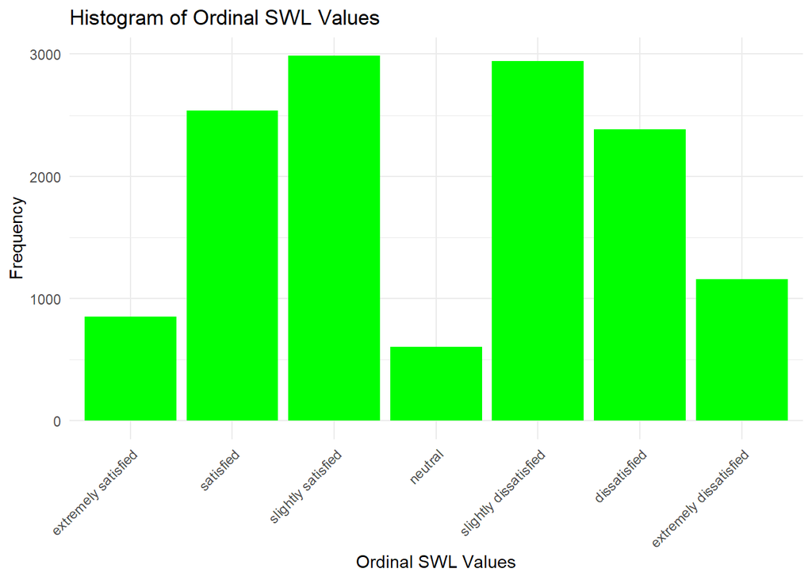

```r
ggplot(df, aes(x = SWL_ord)) +
  geom_bar(fill = "green") +
  labs(title = "Histogram of Ordinal SWL Values",
       x = "Ordinal SWL Values",
       y = "Frequency") +
  theme_minimal() +
  theme(axis.text.x = element_text(angle = 45, hjust = 1))
```

SWL is bimodal, show how the grading scale is different from the other two inventories. The seven classes get more extreme on the ends, with the middle being neutral.

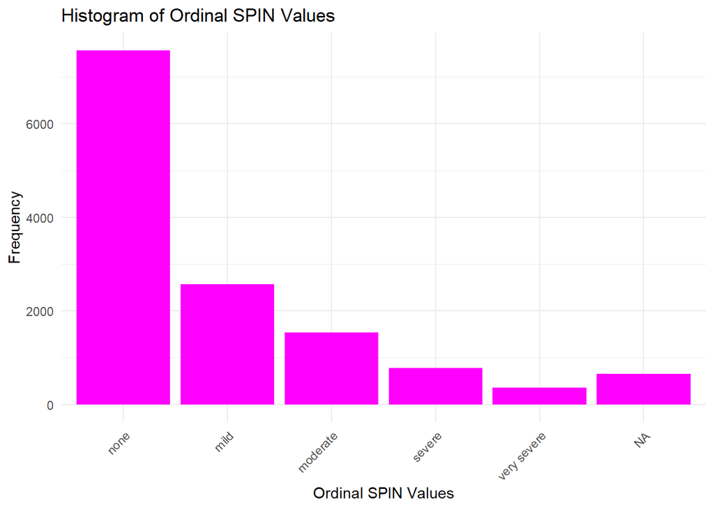

```r
ggplot(df, aes(x = SPIN_ord)) +
  geom_bar(fill = "magenta") +
  labs(title = "Histogram of Ordinal SPIN Values",
       x = "Ordinal SPIN Values",
       y = "Frequency") +
  theme_minimal() +
  theme(axis.text.x = element_text(angle = 45, hjust = 1))
```

SPIN has five levels (NA is later removed).

### Reason for playing

When looking at all of this data, a crucial component is the reason why gamers play video games in the first place. Since this field was a free-response, it would be impossible, and unwise, to display a histogram of every possible response received. In order to show meaningful results, we will use regular expressions to isolate key words in the responses and categorize them under a specific group.

```r
clean_responses <- function(response) {
  response <- trimws(tolower(response))  # Normalize to lowercase and trim whitespace

  # Check for exact matches first
  if (response %in% c("winning", "improving", "relaxing", "having fun")) {
    return(response)
  }

  # Check for various conditions to set the response
  if (str_detect(response, "^a[\\s,\\.]", ) ||
      str_detect(response, "^1[\\s,\\.]", ) ||
      str_detect(response, "^all") ||
      str_detect(response, "^mix") ||
      str_detect(response, "combination") ||
      str_detect(response, "everything")) {
    return("all of the above")
  }

  if (str_detect(response, "distraction|escaping|escape|forget|hide|hiding|depression|boredom|bored|time|forgetting|making my brain go numb|distracting|doing something|getting away from real life|trying to get my mind off")) {
    return("escape")
  }

  if (str_detect(response, "improve|improving|learn|learning")) {
    return("improving")
  }

  if (str_detect(response, "well|perform|performing")) {
    return("winning")
  }

  if (str_detect(response, "social|socializing|friends|team|cooperating|people|the people i play with, the game is less important")) {
    return("social")
  }

  if (str_detect(response, "win|winning|beating|victory|competeing|competing|competition|conpeting")) {
    return("winning")
  }

  if (str_detect(response, "winning") && str_detect(response, "improving")) {
    return("mix")
  }

  if (str_detect(response, "relaxing") && str_detect(response, "fun")) {
    return("mix")
  }

  if (str_detect(response, "combination|all")) {
    return("mix")
  }

  if (str_detect(response, "fun")) {
    return("having fun")
  }

  # Default to original response if no condition is met
  return("bad response")
}

# Apply the cleaning function to the 'whyplay' column
df$cleaned_whyplay <- sapply(df$whyplay, clean_responses)

# Count the occurrences of each cleaned response
whyplay_counts <- as.data.frame(table(df$cleaned_whyplay))
```

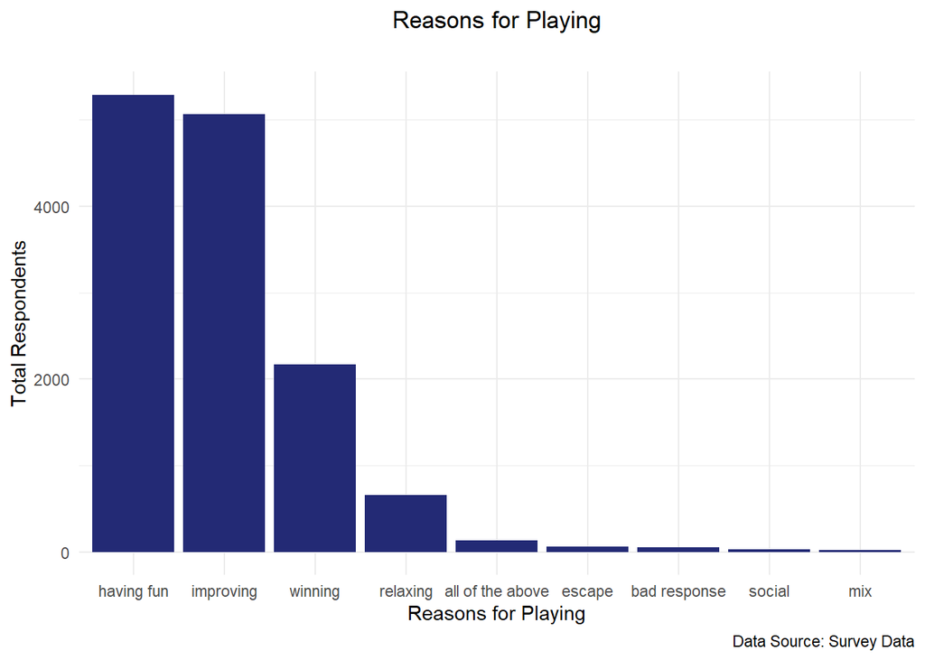

```r
colnames(whyplay_counts) <- c("WhyPlay", "SurveyCount")


whyplay_counts <- whyplay_counts[order(-whyplay_counts$SurveyCount), ]


whyplay_counts$WhyPlay <- factor(whyplay_counts$WhyPlay, levels = whyplay_counts$WhyPlay)


fig <- ggplot(whyplay_counts, aes(x = WhyPlay, y = SurveyCount)) +
  geom_bar(stat = 'identity', fill = '#232A75') +
  labs(title = 'Reasons for Playing',
       subtitle = '',
       caption = 'Data Source: Survey Data',
       x = 'Reasons for Playing',
       y = 'Total Respondents') +
  theme_minimal() +
  theme(plot.title = element_text(hjust = 0.5))


print(fig)
```

Now we can see that most gamers play either for fun or to improve their skills. One quick note: the group ‘Escape’ does not refer to escaping responsibilities. It is more along the lines of dissociation and depression.

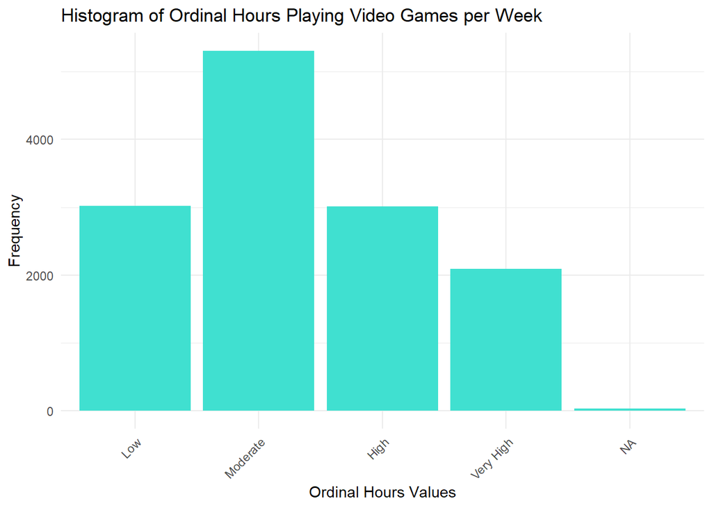

```r
ggplot(df, aes(x = hours_ord)) +
  geom_bar(fill = "turquoise") +
  labs(title = "Histogram of Ordinal Hours Playing Video Games per Week",
       x = "Ordinal Hours Values",
       y = "Frequency") +
  theme_minimal() +
  theme(axis.text.x = element_text(angle = 45, hjust = 1))
```

```r
# Replace missing values in the Hours column with NA explicitly
hrs_data_cleaned <- df %>%
  mutate(Hours = ifelse(is.na(Hours), NA, Hours))
missing_values <- colSums(is.na(hrs_data_cleaned))

# Filter necessary columns
hrs_GAD_filtered <- hrs_data_cleaned %>%
  select(Hours, GAD1:GAD7, GAD_T)
```

```r
# Define the outlierKD2 function
outlierKD2 <- function(dt, var, rm = TRUE, boxplt = TRUE, qqplt = TRUE) {
  var_name <- eval(substitute(var),eval(dt))
  na1 <- sum(is.na(var_name))
  m1 <- mean(var_name, na.rm = TRUE)

  # Generate boxplot and histogram (before removing outliers)
  if (boxplt) {
    par(mfrow = c(2, 2), oma = c(0, 0, 3, 0))
    boxplot(var_name, main = "With outliers")
    hist(var_name, main = "With outliers", xlab = NA, ylab = NA)
  }

  outlier <- boxplot.stats(var_name)$out
  mo <- mean(outlier)

  var_name <- ifelse(var_name %in% outlier, NA, var_name)


  na2 <- sum(is.na(var_name))

  cat("Outliers identified:", na2 - na1, "\n")
  cat("Proportion (%) of outliers:", round((na2 - na1) / sum(!is.na(var_name)) * 100, 1), "\n")
  cat("Mean of the outliers:", round(mo, 2), "\n")
  m2 <- mean(var_name, na.rm = TRUE)
  cat("Mean without removing outliers:", round(m1, 2), "\n")
  cat("Mean if we remove outliers:", round(m2, 2), "\n")

  # Option to remove outliers (replace with NA)
  if (rm) {
    dt[[as.character(substitute(var))]] <- invisible(var_name)
    assign(as.character(as.list(match.call())$dt), dt, envir = .GlobalEnv)
    cat("Outliers successfully removed\n")
    return(invisible(dt))
  } else {
    cat("Nothing changed\n")
    return(invisible(var_name))
  }
}

# Apply outlierKD2 to remove outliers from 'Hours'
hrs_GAD_filtered_clean <- outlierKD2(hrs_GAD_filtered, Hours, rm = TRUE, boxplt = FALSE, qqplt = TRUE)
```

```r
# Define the outlierKD2 function
outlierKD2 <- function(dt, var, rm = TRUE, boxplt = TRUE, qqplt = TRUE) {
  var_name <- eval(substitute(var), eval(dt))
  na1 <- sum(is.na(var_name))
  m1 <- mean(var_name, na.rm = TRUE)


  outlier <- boxplot.stats(var_name)$out
  mo <- mean(outlier)

  var_name <- ifelse(var_name %in% outlier, NA, var_name)

  if (boxplt) {
    boxplot(var_name, main = "Without outliers")
    hist(var_name, main = "Without outliers", xlab = NA, ylab = NA)
  }


  na2 <- sum(is.na(var_name))

  cat("Outliers identified:", na2 - na1, "\n")
  cat("Proportion (%) of outliers:", round((na2 - na1) / sum(!is.na(var_name)) * 100, 1), "\n")
  cat("Mean of the outliers:", round(mo, 2), "\n")
  m2 <- mean(var_name, na.rm = TRUE)
  cat("Mean without removing outliers:", round(m1, 2), "\n")
  cat("Mean if we remove outliers:", round(m2, 2), "\n")

  # Option to remove outliers (replace with NA)
  if (rm) {
    dt[[as.character(substitute(var))]] <- invisible(var_name)
    assign(as.character(as.list(match.call())$dt), dt, envir = .GlobalEnv)
    cat("Outliers successfully removed\n")
    return(invisible(dt))
  } else {
    cat("Nothing changed\n")
    return(invisible(var_name))
  }
}

# Use outlierKD2 to remove outliers from 'streams'
df_clean <- outlierKD2(df, streams, rm = TRUE, boxplt = FALSE, qqplt = TRUE)
```

```r
df_clean$streams_Stand <- scale(df_clean$streams)
hrs_GAD_filtered_clean$hours_Stand <- scale(hrs_GAD_filtered_clean$Hours)
```

### Adding Hours and Streams -> Total Time and generating a histogram

We combine the two time variables (hours and streams) and try to see if the combined data can be used for further analysis.

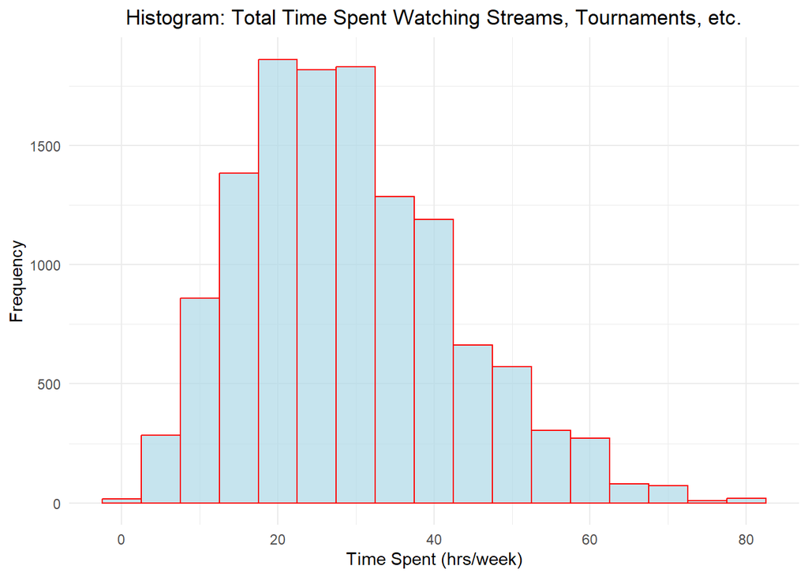

```r
# Create the new column hrs_stream_combined in df
df$hrs_stream_combined <- df_clean$streams + hrs_GAD_filtered_clean$Hours

# Histogram with minimal theme and bin width of 5
ggplot(data = df, aes(x = hrs_stream_combined)) +
  geom_histogram(binwidth = 5, color = "red", fill = "lightblue", alpha = 0.7) +
  labs(title = "Histogram: Total Time Spent Watching Streams, Tournaments, etc.",
       x = "Time Spent (hrs/week)",
       y = "Frequency") +
  theme_minimal() +
  theme(
    plot.title = element_text(hjust = 0.5,),  # Center and bold title
    axis.title.x = element_text(hjust = 0.5), # Bold and center x-axis label
    axis.title.y = element_text(hjust = 0.5)  # Bold and center y-axis label
  )
```

# Linear Regression Modeling

We want to make inferences on how mental health indicator scores and categories affect a person’s time spent playing and streaming video games. In order to start this process, we are first going to guess that there is a linear relationship among all the variables.

### Numeric Scores

We will first start with a linear model that has individual or combined mental health scores as the independent variable(s) and hours playing and streaming as the dependent variable.

```r
# Fit the linear regression models
lm_gad <- lm(hrs_stream_combined ~ GAD_T, data = df)
lm_swl <- lm(hrs_stream_combined ~ SWL_T, data = df)
lm_spin <- lm(hrs_stream_combined ~ SPIN_T, data = df)
lm_3_combined <- lm(hrs_stream_combined ~ GAD_T + SWL_T + SPIN_T, data = df)

# Define the summaries of each model
summary_gad <- summary(lm_gad)
summary_swl <- summary(lm_swl)
summary_spin <- summary(lm_spin)
summary_3_combined <- summary(lm_3_combined)

# Values
## Intercepts and slopes
intercept_gad <- coef(summary_gad)["(Intercept)", "Estimate"]
slope_gad <- coef(summary_gad)["GAD_T", "Estimate"]
## P-value for the slope
p_value_gad <- coef(summary_gad)["GAD_T", "Pr(>|t|)"]
## R-squared and Adjusted R-squared
r_squared_gad <- summary_gad$r.squared
adj_r_squared_gad <- summary_gad$adj.r.squared

# Call the summaries
summary_gad
```

```
##
## Call:
## lm(formula = hrs_stream_combined ~ GAD_T, data = df)
##
## Residuals:
##    Min     1Q Median     3Q    Max
## -31.47  -9.96  -1.76   8.33  52.04
##
## Coefficients:
##             Estimate Std. Error t value Pr(>|t|)
## (Intercept)   27.962      0.179  155.95   <2e-16 ***
## GAD_T          0.237      0.026    9.13   <2e-16 ***
## ---
## Signif. codes:  0 '***' 0.001 '**' 0.01 '*' 0.05 '.' 0.1 ' ' 1
##
## Residual standard error: 13.5 on 12532 degrees of freedom
##   (930 observations deleted due to missingness)
## Multiple R-squared:  0.0066, Adjusted R-squared:  0.00652
## F-statistic: 83.3 on 1 and 12532 DF,  p-value: <2e-16
```

```r
summary_swl
```

```
##
## Call:
## lm(formula = hrs_stream_combined ~ SWL_T, data = df)
##
## Residuals:
##    Min     1Q Median     3Q    Max
## -31.63  -9.79  -1.71   8.37  52.88
##
## Coefficients:
##             Estimate Std. Error t value Pr(>|t|)
## (Intercept)  33.2746     0.3565    93.3   <2e-16 ***
## SWL_T        -0.2052     0.0168   -12.2   <2e-16 ***
## ---
## Signif. codes:  0 '***' 0.001 '**' 0.01 '*' 0.05 '.' 0.1 ' ' 1
##
## Residual standard error: 13.4 on 12532 degrees of freedom
##   (930 observations deleted due to missingness)
## Multiple R-squared:  0.0118, Adjusted R-squared:  0.0117
## F-statistic:  149 on 1 and 12532 DF,  p-value: <2e-16
```

```r
summary_spin
```

```
##
## Call:
## lm(formula = hrs_stream_combined ~ SPIN_T, data = df)
##
## Residuals:
##    Min     1Q Median     3Q    Max
## -32.00  -9.79  -1.79   8.34  52.46
##
## Coefficients:
##             Estimate Std. Error t value Pr(>|t|)
## (Intercept) 27.44996    0.21978   124.9   <2e-16 ***
## SPIN_T       0.08670    0.00932     9.3   <2e-16 ***
## ---
## Signif. codes:  0 '***' 0.001 '**' 0.01 '*' 0.05 '.' 0.1 ' ' 1
##
## Residual standard error: 13.5 on 11941 degrees of freedom
##   (1521 observations deleted due to missingness)
## Multiple R-squared:  0.00719,    Adjusted R-squared:  0.00711
## F-statistic: 86.5 on 1 and 11941 DF,  p-value: <2e-16
```

```r
summary_3_combined
```

```
##
## Call:
## lm(formula = hrs_stream_combined ~ GAD_T + SWL_T + SPIN_T, data = df)
##
## Residuals:
##    Min     1Q Median     3Q    Max
## -33.54  -9.74  -1.75   8.28  52.71
##
## Coefficients:
##             Estimate Std. Error t value Pr(>|t|)
## (Intercept)  30.7098     0.5132   59.84  < 2e-16 ***
## GAD_T         0.0958     0.0311    3.08   0.0021 **
## SWL_T        -0.1487     0.0189   -7.85  4.5e-15 ***
## SPIN_T        0.0468     0.0105    4.46  8.3e-06 ***
## ---
## Signif. codes:  0 '***' 0.001 '**' 0.01 '*' 0.05 '.' 0.1 ' ' 1
##
## Residual standard error: 13.4 on 11939 degrees of freedom
##   (1521 observations deleted due to missingness)
## Multiple R-squared:  0.015,  Adjusted R-squared:  0.0148
## F-statistic: 60.6 on 3 and 11939 DF,  p-value: <2e-16
```

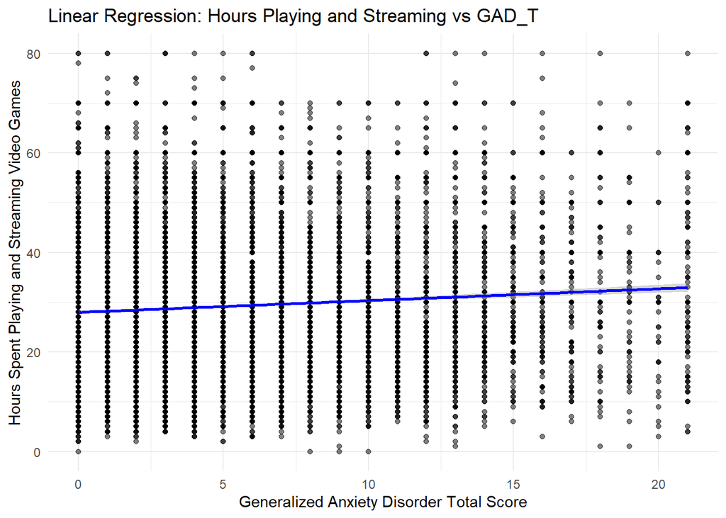

```r
# Visualize the relationship between Hours Playing & Streaming and GAD_T
ggplot(df, aes(x = GAD_T, y = hrs_stream_combined)) +
  geom_point(alpha = 0.5) +
  geom_smooth(method = "lm", col = "blue") +
  labs(title = "Linear Regression: Hours Playing and Streaming vs GAD_T",
       x = "Generalized Anxiety Disorder Total Score",
       y = "Hours Spent Playing and Streaming Video Games") +
  theme_minimal()
```

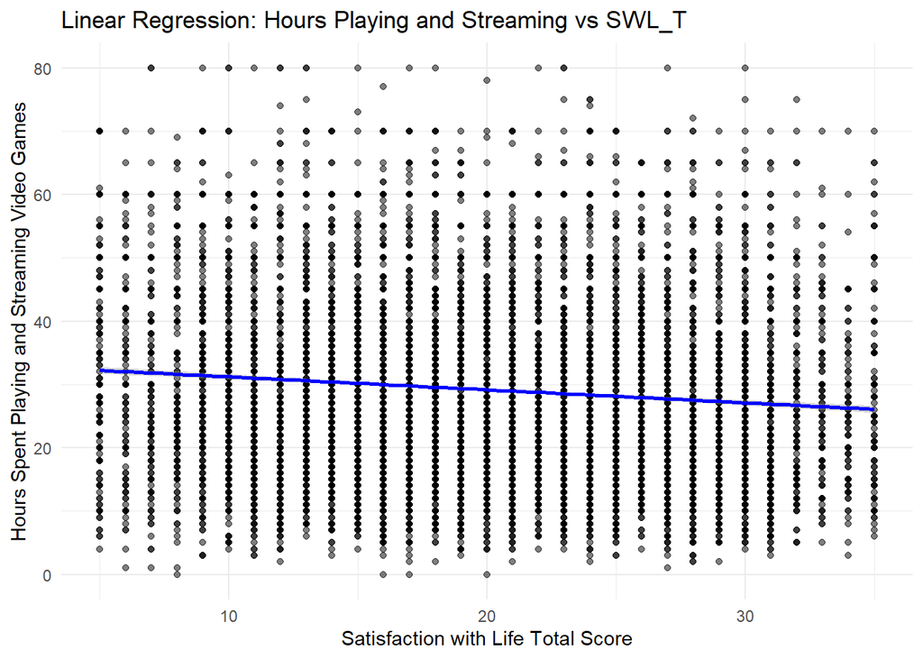

```r
# Visualize the relationship between Hours Playing & Streaming and SWL_T
ggplot(df, aes(x = SWL_T, y = hrs_stream_combined)) +
  geom_point(alpha = 0.5) +
  geom_smooth(method = "lm", col = "blue") +
  labs(title = "Linear Regression: Hours Playing and Streaming vs SWL_T",
       x = "Satisfaction with Life Total Score",
       y = "Hours Spent Playing and Streaming Video Games") +
  theme_minimal()
```

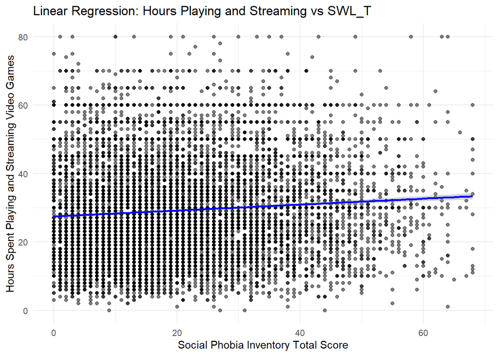

```r
# Visualize the relationship between Hours Playing & Streaming and SPIN_T
ggplot(df, aes(x = SPIN_T, y = hrs_stream_combined)) +
  geom_point(alpha = 0.5) +
  geom_smooth(method = "lm", col = "blue") +
  labs(title = "Linear Regression: Hours Playing and Streaming vs SWL_T",
       x = "Social Phobia Inventory Total Score",
       y = "Hours Spent Playing and Streaming Video Games") +
  theme_minimal()
```

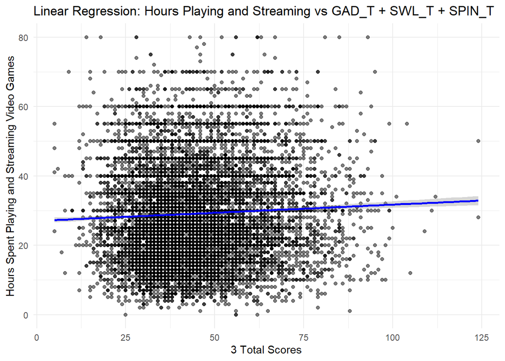

```r
# Visualize the relationship among Hours Playing & Streaming and the three, numeric scores
ggplot(df, aes(x = GAD_T + SWL_T + SPIN_T, y = hrs_stream_combined)) +
  geom_point(alpha = 0.5) +
  geom_smooth(method = "lm", col = "blue") +
  labs(title = "Linear Regression: Hours Playing and Streaming vs GAD_T + SWL_T + SPIN_T",
       x = "3 Total Scores",
       y = "Hours Spent Playing and Streaming Video Games") +
  theme_minimal()
```

#### Outputs of Numeric Models

I will only be talking about the GAD_T model, as similar logic can be applied to SWL_T, SPINT_T, and the combination of the three metrics. The intercept is 27.962. The GAD model is telling us that people in our data set that have a total score of 0 for the GAD-7 questionnaire spends approximately 28 hours playing and streaming video games. The slope of the line of best fit is 0.237, which means that as the score from the questionnaire increases by 1, the amount of hours playing and streaming video games increases by approximately 0.2 hours. However, the scatter plot is showing a huge issue. Players can only receive **integer value scores** when taking the GAD-7 questionnaire. This makes all other values in the models, like Adjusted R Squared and p-values (0.007 and 8.092^{-20} respectively), useless. Before abandoning linear regression models altogether, let’s see how using the ordinal categories for each metric plays out.

### Ordinal Scores

We will see how linear models that have the ordinal categories of each metric functions as the independent variable(s) and hours playing and streaming as the dependent variable.

```r
# Fit the linear regression models
lm_gad_ord <- lm(hrs_stream_combined ~ GAD_ord, data = df)
lm_GADE <- lm(hrs_stream_combined ~ GADE, data = df)
lm_swl_ord <- lm(hrs_stream_combined ~ SWL_ord, data = df)
lm_spin_ord <- lm(hrs_stream_combined ~ SPIN_ord, data = df)
lm_4_ord <- lm(hrs_stream_combined ~ GAD_ord + GADE + SWL_ord + SPIN_ord, data = df)

# Define the summaries of each model
summary_gad_ord <- summary(lm_gad_ord)
summary_GADE <- summary(lm_GADE)
summary_swl_ord <- summary(lm_swl_ord)
summary_spin_ord <- summary(lm_spin_ord)
summary_4_ord <- summary(lm_4_ord)

# Values
## R-squared and Adjusted R-squared
r_squared_gad_ord <- summary_gad_ord$r.squared
adj_r_squared_gad_ord <- summary_gad_ord$adj.r.squared
r_squared_4_ord <- summary_4_ord$r.squared
adj_r_squared_4_ord <- summary_4_ord$adj.r.squared

# Call the summaries
summary_gad_ord
```

```
##
## Call:
## lm(formula = hrs_stream_combined ~ GAD_ord, data = df)
##
## Residuals:
##    Min     1Q Median     3Q    Max
## -31.26  -9.66  -1.51   8.49  51.58
##
## Coefficients:
##             Estimate Std. Error t value Pr(>|t|)
## (Intercept)  30.2132     0.1750  172.61  < 2e-16 ***
## GAD_ord.L     2.8276     0.3866    7.31  2.7e-13 ***
## GAD_ord.Q     0.2530     0.3501    0.72     0.47
## GAD_ord.C     0.0902     0.3093    0.29     0.77
## ---
## Signif. codes:  0 '***' 0.001 '**' 0.01 '*' 0.05 '.' 0.1 ' ' 1
##
## Residual standard error: 13.5 on 12530 degrees of freedom
##   (930 observations deleted due to missingness)
## Multiple R-squared:  0.00594,    Adjusted R-squared:  0.0057
## F-statistic:   25 on 3 and 12530 DF,  p-value: 4.32e-16
```

```r
summary_GADE
```

```
##
## Call:
## lm(formula = hrs_stream_combined ~ GADE, data = df)
##
## Residuals:
##    Min     1Q Median     3Q    Max
## -31.43  -9.42  -1.43   8.57  51.58
##
## Coefficients:
##                          Estimate Std. Error t value Pr(>|t|)
## (Intercept)                34.192      0.732   46.70  < 2e-16 ***
## GADENot difficult at all   -5.768      0.753   -7.66  2.0e-14 ***
## GADESomewhat difficult     -4.818      0.757   -6.36  2.1e-10 ***
## GADEVery difficult         -2.765      0.858   -3.22   0.0013 **
## ---
## Signif. codes:  0 '***' 0.001 '**' 0.01 '*' 0.05 '.' 0.1 ' ' 1
##
## Residual standard error: 13.5 on 11923 degrees of freedom
##   (1537 observations deleted due to missingness)
## Multiple R-squared:  0.00762,    Adjusted R-squared:  0.00737
## F-statistic: 30.5 on 3 and 11923 DF,  p-value: <2e-16
```

```r
summary_swl_ord
```

```
##
## Call:
## lm(formula = hrs_stream_combined ~ SWL_ord, data = df)
##
## Residuals:
##    Min     1Q Median     3Q    Max
## -32.69  -9.72  -1.72   8.28  52.34
##
## Coefficients:
##             Estimate Std. Error t value Pr(>|t|)
## (Intercept) 29.25771    0.14351  203.87  < 2e-16 ***
## SWL_ord.L    4.39213    0.39811   11.03  < 2e-16 ***
## SWL_ord.Q    1.51279    0.44186    3.42  0.00062 ***
## SWL_ord.C    0.24733    0.34059    0.73  0.46773
## SWL_ord^4   -0.00254    0.38466   -0.01  0.99474
## SWL_ord^5    0.06900    0.27112    0.25  0.79912
## SWL_ord^6    0.37941    0.41690    0.91  0.36280
## ---
## Signif. codes:  0 '***' 0.001 '**' 0.01 '*' 0.05 '.' 0.1 ' ' 1
##
## Residual standard error: 13.4 on 12527 degrees of freedom
##   (930 observations deleted due to missingness)
## Multiple R-squared:  0.0127, Adjusted R-squared:  0.0122
## F-statistic: 26.9 on 6 and 12527 DF,  p-value: <2e-16
```

```r
summary_spin_ord
```

```
##
## Call:
## lm(formula = hrs_stream_combined ~ SPIN_ord, data = df)
##
## Residuals:
##    Min     1Q Median     3Q    Max
## -31.23  -9.95  -1.27   8.73  51.73
##
## Coefficients:
##             Estimate Std. Error t value Pr(>|t|)
## (Intercept)   30.290      0.210  144.22   <2e-16 ***
## SPIN_ord.L     2.291      0.537    4.27    2e-05 ***
## SPIN_ord.Q    -0.967      0.493   -1.96     0.05 *
## SPIN_ord.C     0.140      0.445    0.31     0.75
## SPIN_ord^4    -0.087      0.391   -0.22     0.82
## ---
## Signif. codes:  0 '***' 0.001 '**' 0.01 '*' 0.05 '.' 0.1 ' ' 1
##
## Residual standard error: 13.5 on 11938 degrees of freedom
##   (1521 observations deleted due to missingness)
## Multiple R-squared:  0.00686,    Adjusted R-squared:  0.00653
## F-statistic: 20.6 on 4 and 11938 DF,  p-value: <2e-16
```

```r
summary_4_ord
```

```
##
## Call:
## lm(formula = hrs_stream_combined ~ GAD_ord + GADE + SWL_ord +
##     SPIN_ord, data = df)
##
## Residuals:
##    Min     1Q Median     3Q    Max
## -33.77  -9.69  -1.80   8.04  52.64
##
## Coefficients:
##                          Estimate Std. Error t value Pr(>|t|)
## (Intercept)               32.5325     0.7865   41.36  < 2e-16 ***
## GAD_ord.L                  0.8543     0.4873    1.75   0.0796 .
## GAD_ord.Q                  0.2488     0.3751    0.66   0.5072
## GAD_ord.C                  0.1172     0.3172    0.37   0.7118
## GADENot difficult at all  -2.6995     0.8766   -3.08   0.0021 **
## GADESomewhat difficult    -2.7515     0.8469   -3.25   0.0012 **
## GADEVery difficult        -1.7262     0.8925   -1.93   0.0531 .
## SWL_ord.L                  3.1154     0.4571    6.82  9.9e-12 ***
## SWL_ord.Q                  1.1006     0.4707    2.34   0.0194 *
## SWL_ord.C                  0.0585     0.3603    0.16   0.8710
## SWL_ord^4                  0.0869     0.4020    0.22   0.8290
## SWL_ord^5                  0.1487     0.2840    0.52   0.6006
## SWL_ord^6                  0.2779     0.4335    0.64   0.5215
## SPIN_ord.L                 0.5790     0.5734    1.01   0.3126
## SPIN_ord.Q                -1.1788     0.4996   -2.36   0.0183 *
## SPIN_ord.C                -0.0258     0.4470   -0.06   0.9539
## SPIN_ord^4                -0.0577     0.3927   -0.15   0.8832
## ---
## Signif. codes:  0 '***' 0.001 '**' 0.01 '*' 0.05 '.' 0.1 ' ' 1
##
## Residual standard error: 13.4 on 11340 degrees of freedom
##   (2107 observations deleted due to missingness)
## Multiple R-squared:  0.0178, Adjusted R-squared:  0.0164
## F-statistic: 12.8 on 16 and 11340 DF,  p-value: <2e-16
```

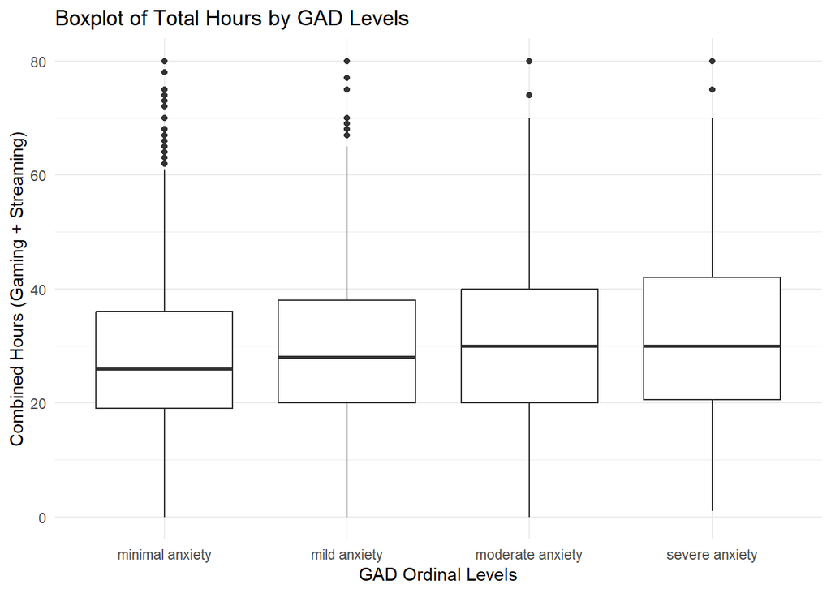

```r
ggplot(df, aes(x = GAD_ord, y = hrs_stream_combined)) +
    geom_boxplot() +
    labs(title = "Boxplot of Total Hours by GAD Levels",
         x = "GAD Ordinal Levels",
         y = "Combined Hours (Gaming + Streaming)") +
    theme_minimal()
```

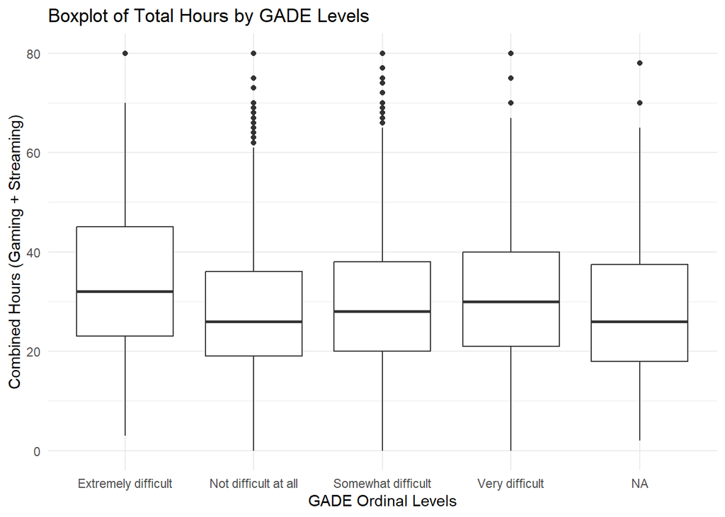

```r
ggplot(df, aes(x = GADE, y = hrs_stream_combined)) +
    geom_boxplot() +
    labs(title = "Boxplot of Total Hours by GADE Levels",
         x = "GADE Ordinal Levels",
         y = "Combined Hours (Gaming + Streaming)") +
    theme_minimal()
```

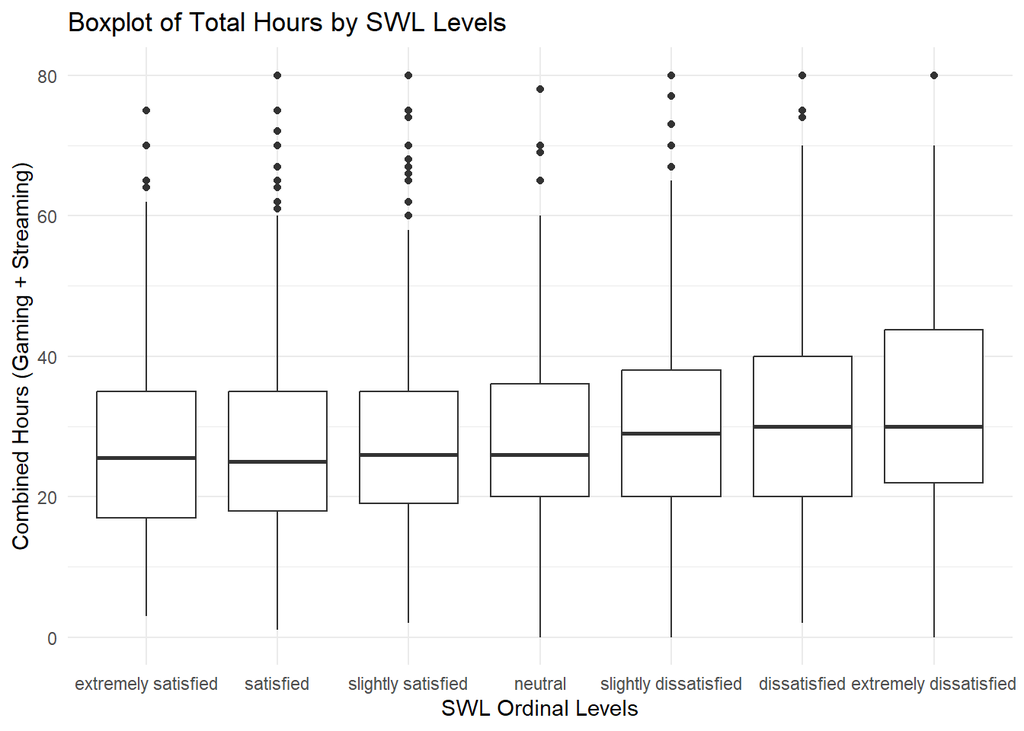

```r
ggplot(df, aes(x = SWL_ord, y = hrs_stream_combined)) +
    geom_boxplot() +
    labs(title = "Boxplot of Total Hours by SWL Levels",
         x = "SWL Ordinal Levels",
         y = "Combined Hours (Gaming + Streaming)") +
    theme_minimal()
```

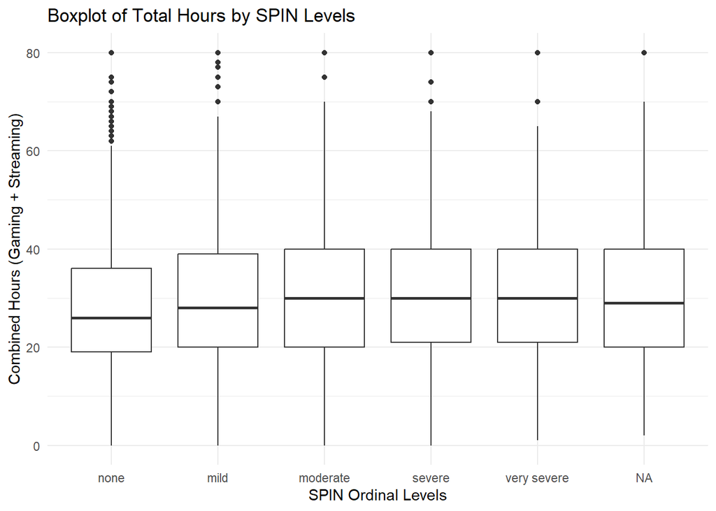

```r
ggplot(df, aes(x = SPIN_ord, y = hrs_stream_combined)) +
    geom_boxplot() +
    labs(title = "Boxplot of Total Hours by SPIN Levels",
         x = "SPIN Ordinal Levels",
         y = "Combined Hours (Gaming + Streaming)") +
    theme_minimal()
```

#### Outputs of Ordinal Models

Similarly with the numeric models, I will mostly only discuss the GAD_T model, as the logic for the other models is similar. Using ordinal categories was much better than raw, numeric scores. We get a clear depiction of median hours spent playing and streaming video games based on the category players align to. However, there is still a significant issue. While everything is set up correctly, we receive an R-squared value of 0.006; the adjusted R-squared value is 0.006. This means that the model only 0% of the variance in the ordinal GAD categories is accounted for. Even using the model that combines all the ordinal categories, including GADE, yields an adjusted R-squared value of 0.016, meaning only 0% of the variance is accounted for. This evidence informs us that there is not a linear relationship among the metrics in the data set and hours spent playing and streaming video games. Linear regression is not the correct type of regression to perform for this analysis, so we will have to use logistic regression.

# Logistic Regression

According to the American Academy of Pediatrics (AAP), teens and adults should be limited to two hours of daily entertainment (Cam Adair, 2016; NIH, 2013). It has been also found that those with three or more hours of screen time were 34% more likely to have a “suicide-related outcome,” meaning suicidal ideation, suicidal plan and/or suicide attempt. Those with five or more hours of screen time were 48% more likely to have a suicide-related outcome (Mary Fristad, 2019). This means playing in between 14-15 hrs/week is considered to be a healthy amount of time spent on screentime. That means the threshold of 15 hours/ week can be considered as normal limit of online streaming and gaming.

We proceed to develop a logistic regression model. Our goal is to identify key factors that influence whether a person’s combined hours spent on gaming and streaming exceed 15 hours a week and to assess the effectiveness of our models in making these predictions.

```r
# Create the binary variable indicating whether the combined hours are greater than 15
df$hrs_stream_binary <- ifelse(df$hrs_stream_combined > 15, 1, 0)
table(df$hrs_stream_binary)
```

```
##
##     0     1
##  2017 10517
```

### Converting categorical variables as factor variables

The categorical variables that we think could have an influence on hours played/ week have been converted into factors in order to proceed with the next steps.

```r
df$SPIN_ord <- as.factor(df$SPIN_ord)
df$GAD_ord <- as.factor(df$GAD_ord)
df$SWL_ord <- as.factor(df$SWL_ord)
df$cleaned_whyplay <- as.factor(df$cleaned_whyplay)
df$Gender <- as.factor(df$Gender)
df$Game <- as.factor(df$Game)
df$Work <- as.factor(df$Work)
df$Degree <- as.factor(df$Degree)
df$Platform <- as.factor(df$Platform)
df$GADE <- as.factor(df$GADE)
```

### T-test and Chi-square tests

Before building the model, we find out if the predictors we think could have an influence on hours played per week actually have any relationship with the dependent variable.

```r
# Perform a t-test to compare the mean ages of those who have different HoursBinary values
t.test(df$Age ~ df$hrs_stream_binary)
```

```
##
##  Welch Two Sample t-test
##
## data:  df$Age by df$hrs_stream_binary
## t = 3, df = 2628, p-value = 7e-04
## alternative hypothesis: true difference in means between group 0 and group 1 is not equal to 0
## 95 percent confidence interval:
##  0.128 0.475
## sample estimates:
## mean in group 0 mean in group 1
##            21.2            20.9
```

```r
# Chi-squared test for SPIN_ord and hrs_stream_binary
table_SPIN_ord <- table(df$SPIN_ord, df$hrs_stream_binary)
chisq.test(table_SPIN_ord)
```

```
##
##  Pearson's Chi-squared test
##
## data:  table_SPIN_ord
## X-squared = 19, df = 4, p-value = 7e-04
```

```r
# Chi-squared test for GAD_ord and hrs_stream_binary
table_GAD_ord <- table(df$GAD_ord, df$hrs_stream_binary)
chisq.test(table_GAD_ord)
```

```
##
##  Pearson's Chi-squared test
##
## data:  table_GAD_ord
## X-squared = 6, df = 3, p-value = 0.1
```

```r
# Chi-squared test for SWL_ord and hrs_stream_binary
table_SWL_ord <- table(df$SWL_ord, df$hrs_stream_binary)
chisq.test(table_SWL_ord)
```

```
##
##  Pearson's Chi-squared test
##
## data:  table_SWL_ord
## X-squared = 37, df = 6, p-value = 2e-06
```

```r
# Chi-squared test for Work and hrs_stream_binary
table_Work <- table(df$Work, df$hrs_stream_binary)
chisq.test(table_Work)
```

```
##
##  Pearson's Chi-squared test
##
## data:  table_Work
## X-squared = 39, df = 3, p-value = 2e-08
```

```r
# Chi-squared test for Gender and hrs_stream_binary
table_Gender <- table(df$Gender, df$hrs_stream_binary)
chisq.test(table_Gender)
```

```
##
##  Pearson's Chi-squared test
##
## data:  table_Gender
## X-squared = 55, df = 2, p-value = 1e-12
```

```r
# Chi-squared test for Game and hrs_stream_binary
table_Game <- table(df$Game, df$hrs_stream_binary)
chisq.test(table_Game)
```

```
##
##  Pearson's Chi-squared test
##
## data:  table_Game
## X-squared = 65, df = 10, p-value = 4e-10
```

```r
# Chi-squared test for Platform and hrs_stream_binary
table_Platform <- table(df$Platform, df$hrs_stream_binary)
chisq.test(table_Platform)
```

```
##
##  Pearson's Chi-squared test
##
## data:  table_Platform
## X-squared = 54, df = 2, p-value = 2e-12
```

```r
# Chi-squared test for GADE and hrs_stream_binary
table_GADE <- table(df$GADE, df$hrs_stream_binary)
chisq.test(table_GADE)
```

```
##
##  Pearson's Chi-squared test
##
## data:  table_GADE
## X-squared = 11, df = 3, p-value = 0.01
```

```r
# Chi-squared test for cleaned_whyplay and hrs_stream_binary
table_cleaned_whyplay <- table(df$cleaned_whyplay, df$hrs_stream_binary)
chisq.test(table_cleaned_whyplay)
```

```
##
##  Pearson's Chi-squared test
##
## data:  table_cleaned_whyplay
## X-squared = 206, df = 8, p-value <2e-16
```

The results suggest that the variables Age, SPIN_ord, SWL_ord, Work, Gender, Game, Platform, GADE, and cleaned_whyplay are likely to be good predictors of hrs_stream_binary based on the significance of their associations. GAD_ord gives Non-significant chi-squared result (p-value = 0.1), suggesting it is not a good predictor.

Now in order to proceed with the model building, we need to ensure that the assumptions of logistic regression are met. Two of these assumptions like the dependent variable should be binary, the observations should be independent of each other have been already met. We now check the Linearity of Logits, that there is no multicollinearity and strong outliers in the data set.

### Test the linearity of continuous predictors

In order to check this, we need to see if the relationship between continuous independent variable (Age) and the logit (log-odds) of the dependent variable is linear or not. We use the Box-Tidwell test to do this:

```r
# Box-Tidwell test for continuous variables
df$Age_log <- log(df$Age + 1) * df$Age

# Fit the model including the interaction terms only for continuous variables
model_interaction_cont <- glm(hrs_stream_binary ~ SPIN_ord + SWL_ord + Age + Work + Gender + Game + Platform + GADE + cleaned_whyplay + Age_log, data = df, family = binomial)
summary(model_interaction_cont)
```

```
##
## Call:
## glm(formula = hrs_stream_binary ~ SPIN_ord + SWL_ord + Age +
##     Work + Gender + Game + Platform + GADE + cleaned_whyplay +
##     Age_log, family = binomial, data = df)
##
## Coefficients:
##                                     Estimate Std. Error z value Pr(>|z|)
## (Intercept)                         -2.19384    1.45351   -1.51  0.13121
## SPIN_ord.L                           0.12063    0.12483    0.97  0.33387
## SPIN_ord.Q                          -0.06580    0.10969   -0.60  0.54857
## SPIN_ord.C                           0.11780    0.09657    1.22  0.22256
## SPIN_ord^4                           0.05542    0.08485    0.65  0.51363
## SWL_ord.L                            0.17031    0.09401    1.81  0.07004 .
## SWL_ord.Q                           -0.22664    0.09724   -2.33  0.01977 *
## SWL_ord.C                            0.00625    0.07370    0.08  0.93243
## SWL_ord^4                           -0.01419    0.08432   -0.17  0.86639
## SWL_ord^5                            0.03948    0.05918    0.67  0.50472
## SWL_ord^6                           -0.02452    0.09217   -0.27  0.79023
## Age                                  0.71045    0.24476    2.90  0.00370 **
## WorkStudent at college / university  0.03961    0.07533    0.53  0.59900
## WorkStudent at school                0.08768    0.10650    0.82  0.41037
## WorkUnemployed / between jobs        0.51561    0.11890    4.34  1.4e-05 ***
## GenderMale                           0.66236    0.09901    6.69  2.2e-11 ***
## GenderOther                          0.82394    0.49904    1.65  0.09873 .
## GameDestiny                         -0.06791    0.62822   -0.11  0.91391
## GameDiablo 3                         0.39438    0.47528    0.83  0.40666
## GameGuild Wars 2                     0.42705    0.64918    0.66  0.51065
## GameHearthstone                     -0.53813    0.35514   -1.52  0.12970
## GameHeroes of the Storm             -0.33466    0.49814   -0.67  0.50171
## GameLeague of Legends               -0.31384    0.20136   -1.56  0.11909
## GameOther                           -0.61416    0.21890   -2.81  0.00502 **
## GameSkyrim                          -0.91913    0.52261   -1.76  0.07862 .
## GameStarcraft 2                     -0.87104    0.24726   -3.52  0.00043 ***
## GameWorld of Warcraft                0.19405    0.35821    0.54  0.58800
## PlatformPC                           0.75664    0.17366    4.36  1.3e-05 ***
## PlatformSmartphone / Tablet          0.21991    0.56398    0.39  0.69659
## GADENot difficult at all            -0.21909    0.18707   -1.17  0.24155
## GADESomewhat difficult              -0.18552    0.18476   -1.00  0.31532
## GADEVery difficult                  -0.09031    0.20201   -0.45  0.65483
## cleaned_whyplaybad response         -0.65304    0.53717   -1.22  0.22410
## cleaned_whyplayescape               -0.95769    0.51713   -1.85  0.06403 .
## cleaned_whyplayhaving fun           -0.93478    0.33561   -2.79  0.00535 **
## cleaned_whyplayimproving            -0.27863    0.33710   -0.83  0.40850
## cleaned_whyplaymix                  -0.39870    0.83999   -0.47  0.63503
## cleaned_whyplayrelaxing             -1.23645    0.34776   -3.56  0.00038 ***
## cleaned_whyplaysocial               -0.45540    0.70878   -0.64  0.52054
## cleaned_whyplaywinning              -0.45726    0.34126   -1.34  0.18027
## Age_log                             -0.17272    0.05814   -2.97  0.00297 **
## ---
## Signif. codes:  0 '***' 0.001 '**' 0.01 '*' 0.05 '.' 0.1 ' ' 1
##
## (Dispersion parameter for binomial family taken to be 1)
##
##     Null deviance: 9969.5  on 11327  degrees of freedom
## Residual deviance: 9589.8  on 11287  degrees of freedom
##   (2136 observations deleted due to missingness)
## AIC: 9672
##
## Number of Fisher Scoring iterations: 4
```

The coefficient suggests that the relationship between Age and the log-odds of the outcome is not strictly linear. So we now include a quadratic term for Age to capture non-linearity without creating high multicollinearity.

```r
# Create quadratic term for Age
df$Age2 <- df$Age^2

# Fit the model with Age and Age^2
model_poly <- glm(hrs_stream_binary ~ SPIN_ord + SWL_ord + Age + Age2 + Work + Gender + Game + Platform + GADE + cleaned_whyplay, data = df, family = binomial)

# Summarize the model
summary(model_poly)
```

```
##
## Call:
## glm(formula = hrs_stream_binary ~ SPIN_ord + SWL_ord + Age +
##     Age2 + Work + Gender + Game + Platform + GADE + cleaned_whyplay,
##     family = binomial, data = df)
##
## Coefficients:
##                                     Estimate Std. Error z value Pr(>|z|)
## (Intercept)                         -0.00495    0.84012   -0.01  0.99529
## SPIN_ord.L                           0.11982    0.12482    0.96  0.33712
## SPIN_ord.Q                          -0.06566    0.10968   -0.60  0.54938
## SPIN_ord.C                           0.11742    0.09657    1.22  0.22401
## SPIN_ord^4                           0.05528    0.08485    0.65  0.51472
## SWL_ord.L                            0.17163    0.09400    1.83  0.06786 .
## SWL_ord.Q                           -0.22655    0.09724   -2.33  0.01982 *
## SWL_ord.C                            0.00631    0.07370    0.09  0.93172
## SWL_ord^4                           -0.01390    0.08432   -0.16  0.86907
## SWL_ord^5                            0.03941    0.05918    0.67  0.50539
## SWL_ord^6                           -0.02484    0.09217   -0.27  0.78755
## Age                                  0.13495    0.05518    2.45  0.01447 *
## Age2                                -0.00300    0.00108   -2.77  0.00557 **
## WorkStudent at college / university  0.04094    0.07536    0.54  0.58693
## WorkStudent at school                0.07855    0.10604    0.74  0.45886
## WorkUnemployed / between jobs        0.51817    0.11896    4.36  1.3e-05 ***
## GenderMale                           0.66156    0.09900    6.68  2.4e-11 ***
## GenderOther                          0.82344    0.49900    1.65  0.09890 .
## GameDestiny                         -0.06560    0.62836   -0.10  0.91685
## GameDiablo 3                         0.39630    0.47527    0.83  0.40437
## GameGuild Wars 2                     0.42960    0.64915    0.66  0.50811
## GameHearthstone                     -0.53671    0.35513   -1.51  0.13071
## GameHeroes of the Storm             -0.33419    0.49807   -0.67  0.50224
## GameLeague of Legends               -0.31307    0.20136   -1.55  0.12000
## GameOther                           -0.61337    0.21889   -2.80  0.00508 **
## GameSkyrim                          -0.92062    0.52243   -1.76  0.07804 .
## GameStarcraft 2                     -0.87095    0.24723   -3.52  0.00043 ***
## GameWorld of Warcraft                0.19478    0.35813    0.54  0.58652
## PlatformPC                           0.75591    0.17364    4.35  1.3e-05 ***
## PlatformSmartphone / Tablet          0.22283    0.56524    0.39  0.69342
## GADENot difficult at all            -0.21884    0.18705   -1.17  0.24202
## GADESomewhat difficult              -0.18524    0.18474   -1.00  0.31602
## GADEVery difficult                  -0.09000    0.20199   -0.45  0.65590
## cleaned_whyplaybad response         -0.65312    0.53706   -1.22  0.22395
## cleaned_whyplayescape               -0.95838    0.51707   -1.85  0.06381 .
## cleaned_whyplayhaving fun           -0.93545    0.33560   -2.79  0.00531 **
## cleaned_whyplayimproving            -0.27938    0.33709   -0.83  0.40722
## cleaned_whyplaymix                  -0.40146    0.84006   -0.48  0.63273
## cleaned_whyplayrelaxing             -1.23726    0.34775   -3.56  0.00037 ***
## cleaned_whyplaysocial               -0.45587    0.70872   -0.64  0.52007
## cleaned_whyplaywinning              -0.45821    0.34125   -1.34  0.17935
## ---
## Signif. codes:  0 '***' 0.001 '**' 0.01 '*' 0.05 '.' 0.1 ' ' 1
##
## (Dispersion parameter for binomial family taken to be 1)
##
##     Null deviance: 9969.5  on 11327  degrees of freedom
## Residual deviance: 9590.6  on 11287  degrees of freedom
##   (2136 observations deleted due to missingness)
## AIC: 9673
##
## Number of Fisher Scoring iterations: 4
```

### Check for multicollinearity

We then check for multicollinearity using the Variance Inflation Factor (VIF):

```r
# Check VIF
library(car)
vif(model_poly)
```

```
##                  GVIF Df GVIF^(1/(2*Df))
## SPIN_ord         1.25  4            1.03
## SWL_ord          1.31  6            1.02
## Age             54.64  1            7.39
## Age2            51.62  1            7.18
## Work             1.76  3            1.10
## Gender           1.07  2            1.02
## Game             1.30 10            1.01
## Platform         1.22  2            1.05
## GADE             1.31  3            1.05
## cleaned_whyplay  1.09  8            1.01
```

We find that the VIF values of Age and Age^2 are greater than 10. We consider using spline functions to model the non-linear relationship more flexibly and potentially reduce this multicollinearity.

```r
library(splines)

# Fit the model using splines for Age
model_spline <- glm(hrs_stream_binary ~ SPIN_ord + SWL_ord + ns(Age, df=3) + Work + Gender + Game + Platform + GADE + cleaned_whyplay, data = df, family = binomial)

# Summarize the model
summary(model_spline)
```

```
##
## Call:
## glm(formula = hrs_stream_binary ~ SPIN_ord + SWL_ord + ns(Age,
##     df = 3) + Work + Gender + Game + Platform + GADE + cleaned_whyplay,
##     family = binomial, data = df)
##
## Coefficients:
##                                     Estimate Std. Error z value Pr(>|z|)
## (Intercept)                          1.39026    0.47059    2.95  0.00313 **
## SPIN_ord.L                           0.12040    0.12486    0.96  0.33491
## SPIN_ord.Q                          -0.06628    0.10972   -0.60  0.54576
## SPIN_ord.C                           0.11850    0.09659    1.23  0.21987
## SPIN_ord^4                           0.05560    0.08486    0.66  0.51232
## SWL_ord.L                            0.16616    0.09406    1.77  0.07732 .
## SWL_ord.Q                           -0.22622    0.09725   -2.33  0.02002 *
## SWL_ord.C                            0.00504    0.07371    0.07  0.94546
## SWL_ord^4                           -0.01374    0.08433   -0.16  0.87061
## SWL_ord^5                            0.03940    0.05918    0.67  0.50555
## SWL_ord^6                           -0.02469    0.09219   -0.27  0.78880
## ns(Age, df = 3)1                     0.00361    0.31021    0.01  0.99071
## ns(Age, df = 3)2                    -1.29101    0.61509   -2.10  0.03583 *
## ns(Age, df = 3)3                    -2.97288    1.29760   -2.29  0.02196 *
## WorkStudent at college / university  0.02290    0.07627    0.30  0.76393
## WorkStudent at school                0.12157    0.10896    1.12  0.26452
## WorkUnemployed / between jobs        0.50333    0.11907    4.23  2.4e-05 ***
## GenderMale                           0.66273    0.09903    6.69  2.2e-11 ***
## GenderOther                          0.83261    0.49922    1.67  0.09535 .
## GameDestiny                         -0.05591    0.62831   -0.09  0.92910
## GameDiablo 3                         0.38654    0.47534    0.81  0.41611
## GameGuild Wars 2                     0.42623    0.64949    0.66  0.51166
## GameHearthstone                     -0.54709    0.35492   -1.54  0.12321
## GameHeroes of the Storm             -0.33306    0.49833   -0.67  0.50391
## GameLeague of Legends               -0.31546    0.20140   -1.57  0.11727
## GameOther                           -0.61852    0.21896   -2.82  0.00473 **
## GameSkyrim                          -0.90592    0.52258   -1.73  0.08300 .
## GameStarcraft 2                     -0.87100    0.24730   -3.52  0.00043 ***
## GameWorld of Warcraft                0.19286    0.35828    0.54  0.59039
## PlatformPC                           0.75703    0.17372    4.36  1.3e-05 ***
## PlatformSmartphone / Tablet          0.20281    0.55927    0.36  0.71687
## GADENot difficult at all            -0.21770    0.18710   -1.16  0.24461
## GADESomewhat difficult              -0.18382    0.18478   -0.99  0.31984
## GADEVery difficult                  -0.08706    0.20204   -0.43  0.66654
## cleaned_whyplaybad response         -0.66164    0.53754   -1.23  0.21838
## cleaned_whyplayescape               -0.96261    0.51705   -1.86  0.06264 .
## cleaned_whyplayhaving fun           -0.93400    0.33565   -2.78  0.00539 **
## cleaned_whyplayimproving            -0.27842    0.33714   -0.83  0.40890
## cleaned_whyplaymix                  -0.37722    0.84034   -0.45  0.65351
## cleaned_whyplayrelaxing             -1.23353    0.34781   -3.55  0.00039 ***
## cleaned_whyplaysocial               -0.45670    0.70910   -0.64  0.51954
## cleaned_whyplaywinning              -0.45519    0.34130   -1.33  0.18231
## ---
## Signif. codes:  0 '***' 0.001 '**' 0.01 '*' 0.05 '.' 0.1 ' ' 1
##
## (Dispersion parameter for binomial family taken to be 1)
##
##     Null deviance: 9969.5  on 11327  degrees of freedom
## Residual deviance: 9587.6  on 11286  degrees of freedom
##   (2136 observations deleted due to missingness)
## AIC: 9672
##
## Number of Fisher Scoring iterations: 4
```

```r
# Check VIF
vif(model_spline)
```

```
##                 GVIF Df GVIF^(1/(2*Df))
## SPIN_ord        1.25  4            1.03
## SWL_ord         1.31  6            1.02
## ns(Age, df = 3) 2.08  3            1.13
## Work            2.13  3            1.13
## Gender          1.07  2            1.02
## Game            1.30 10            1.01
## Platform        1.22  2            1.05
## GADE            1.31  3            1.05
## cleaned_whyplay 1.10  8            1.01
```

Now we see that the VIF of all the independent variables are within limits.

### Check influence of Strong Outliers

### Identify and Remove Rows with Missing Values for Model Variables

We examine standardized residuals and leverage values to identify outliers and influential points. But before that we need to identify and remove the missing values from the dataset.

```r
# Check for missing values
colSums(is.na(df))
```

```
##              S..No.           Timestamp                GAD1                GAD2
##                   0                   0                   0                   0
##                GAD3                GAD4                GAD5                GAD6
##                   0                   0                   0                   0
##                GAD7                GADE                SWL1                SWL2
##                   0                 649                   0                   0
##                SWL3                SWL4                SWL5                Game
##                   0                   0                   0                   0
##            Platform               Hours            earnings             whyplay
##                   0                  30                   0                   0
##              League       highestleague             streams               SPIN1
##                1745               13464                 548                 124
##               SPIN2               SPIN3               SPIN4               SPIN5
##                 154                 140                 159                 166
##               SPIN6               SPIN7               SPIN8               SPIN9
##                 156                 138                 144                 158
##              SPIN10              SPIN11              SPIN12              SPIN13
##                 160                 187                 168                 187
##              SPIN14              SPIN15              SPIN16              SPIN17
##                 156                 147                 147                 175
##          Narcissism              Gender                 Age                Work
##                  23                   0                   0                  38
##              Degree          Birthplace           Residence           Reference
##                   0                   0                   0                  15
##           Playstyle              accept               GAD_T               SWL_T
##                   0                 414                   0                   0
##              SPIN_T      Residence_ISO3     Birthplace_ISO3             GAD_ord
##                 650                 110                 121                   0
##             SWL_ord            SPIN_ord           hours_ord     cleaned_whyplay
##                   0                 650                  30                   0
## hrs_stream_combined   hrs_stream_binary             Age_log                Age2
##                 930                 930                   0                   0
```

We find that there are several missing values in the dataset which are removed in the next step.

```r
# Define the variables used in the model
model_vars <- c("hrs_stream_binary", "SPIN_ord", "GAD_ord", "SWL_ord", "Age", "Work", "Gender", "Game", "Platform", "GADE", "cleaned_whyplay")

# Create a subset of the data frame with only the model variables
df_model <- df[, model_vars]

# Remove rows with any missing values in the model variables
df_clean <- na.omit(df_model)
```

### Calculate Standardized Residuals and Leverage Values and generate Influence Plot

Now, we fit the model using the cleaned data frame, calculate the standardized residuals and leverage values and add them to the cleaned data frame. Next, we use diagnostic plots (e.g., Cook’s distance, leverage) to identify and potentially address any influential observations.

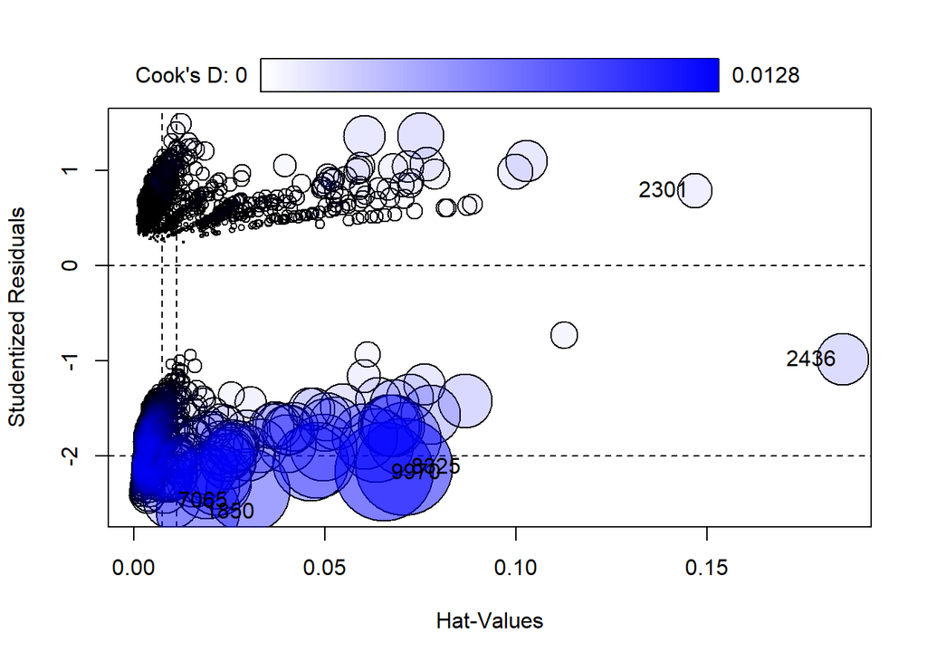

```
##      StudRes     Hat   CookD
## 1850  -2.581 0.01681 0.00918
## 2301   0.792 0.14679 0.00158
## 2436  -0.985 0.18554 0.00353
## 7065  -2.465 0.00981 0.00431
## 8325  -2.115 0.07074 0.01238
## 9970  -2.167 0.06549 0.01276
```

```r
# Fit the logistic regression model using the cleaned data
model <- glm(hrs_stream_binary ~ SPIN_ord + SWL_ord + ns(Age, df = 3) + Work + Gender + Game + Platform + GADE + cleaned_whyplay,
             family = binomial, data = df_clean)

# Calculate standardized residuals
df_clean$residuals <- rstandard(model)

# Calculate leverage values
df_clean$leverage <- hatvalues(model)

# Generate the influence plot
influencePlot(model)
```

The leverage values are mostly moderate. There are no extremely high leverage values that would be of significant concern. All Cook’s distances are well below 1, indicating that no single observation is overly influential on the model’s fit.

### Model Assessment

Now, we will proceed to assess the significance of each predictor by examining the p-values of the coefficients, creating a confusion matrix using a chosen cut-off value (e.g., 0.5) and evaluate other metrics.

```r
# 1. Coefficients’ p-values
summary(model)
```

```
##
## Call:
## glm(formula = hrs_stream_binary ~ SPIN_ord + SWL_ord + ns(Age,
##     df = 3) + Work + Gender + Game + Platform + GADE + cleaned_whyplay,
##     family = binomial, data = df_clean)
##
## Coefficients:
##                                     Estimate Std. Error z value Pr(>|z|)
## (Intercept)                           1.3905     0.4706    2.95  0.00313 **
## SPIN_ord.L                            0.1204     0.1249    0.96  0.33476
## SPIN_ord.Q                           -0.0663     0.1097   -0.60  0.54565
## SPIN_ord.C                            0.1185     0.0966    1.23  0.21984
## SPIN_ord^4                            0.0556     0.0849    0.66  0.51218
## SWL_ord.L                             0.1662     0.0941    1.77  0.07726 .
## SWL_ord.Q                            -0.2263     0.0973   -2.33  0.01999 *
## SWL_ord.C                             0.0051     0.0737    0.07  0.94486
## SWL_ord^4                            -0.0138     0.0843   -0.16  0.87008
## SWL_ord^5                             0.0394     0.0592    0.67  0.50541
## SWL_ord^6                            -0.0247     0.0922   -0.27  0.78904
## ns(Age, df = 3)1                      0.0302     0.2651    0.11  0.90931
## ns(Age, df = 3)2                     -0.8836     0.4340   -2.04  0.04176 *
## ns(Age, df = 3)3                     -2.1889     0.8917   -2.45  0.01409 *
## WorkStudent at college / university   0.0228     0.0763    0.30  0.76455
## WorkStudent at school                 0.1214     0.1090    1.11  0.26514
## WorkUnemployed / between jobs         0.5030     0.1191    4.23  2.4e-05 ***
## GenderMale                            0.6627     0.0990    6.69  2.2e-11 ***
## GenderOther                           0.8325     0.4992    1.67  0.09541 .
## GameDestiny                          -0.0562     0.6283   -0.09  0.92873
## GameDiablo 3                          0.3866     0.4753    0.81  0.41604
## GameGuild Wars 2                      0.4261     0.6495    0.66  0.51178
## GameHearthstone                      -0.5471     0.3549   -1.54  0.12324
## GameHeroes of the Storm              -0.3330     0.4983   -0.67  0.50402
## GameLeague of Legends                -0.3155     0.2014   -1.57  0.11724
## GameOther                            -0.6185     0.2190   -2.82  0.00473 **
## GameSkyrim                           -0.9059     0.5226   -1.73  0.08302 .
## GameStarcraft 2                      -0.8709     0.2473   -3.52  0.00043 ***
## GameWorld of Warcraft                 0.1929     0.3583    0.54  0.59028
## PlatformPC                            0.7571     0.1737    4.36  1.3e-05 ***
## PlatformSmartphone / Tablet           0.2019     0.5590    0.36  0.71796
## GADENot difficult at all             -0.2178     0.1871   -1.16  0.24444
## GADESomewhat difficult               -0.1839     0.1848   -1.00  0.31964
## GADEVery difficult                   -0.0872     0.2020   -0.43  0.66617
## cleaned_whyplaybad response          -0.6614     0.5375   -1.23  0.21852
## cleaned_whyplayescape                -0.9624     0.5171   -1.86  0.06269 .
## cleaned_whyplayhaving fun            -0.9339     0.3357   -2.78  0.00539 **
## cleaned_whyplayimproving             -0.2783     0.3372   -0.83  0.40905
## cleaned_whyplaymix                   -0.3774     0.8403   -0.45  0.65336
## cleaned_whyplayrelaxing              -1.2335     0.3478   -3.55  0.00039 ***
## cleaned_whyplaysocial                -0.4566     0.7091   -0.64  0.51966
## cleaned_whyplaywinning               -0.4551     0.3413   -1.33  0.18238
## ---
## Signif. codes:  0 '***' 0.001 '**' 0.01 '*' 0.05 '.' 0.1 ' ' 1
##
## (Dispersion parameter for binomial family taken to be 1)
##
##     Null deviance: 9969.5  on 11327  degrees of freedom
## Residual deviance: 9587.6  on 11286  degrees of freedom
## AIC: 9672
##
## Number of Fisher Scoring iterations: 4
```

```r
# 2. Confusion Matrix and Accuracy
predicted_prob <- predict(model, type = "response")
predicted_class <- ifelse(predicted_prob > 0.5, 1, 0)
conf_matrix <- table(Predicted = predicted_class, Actual = df_clean$hrs_stream_binary)

# Accuracy
accuracy <- sum(diag(conf_matrix)) / sum(conf_matrix)
print(accuracy)
```

```
## [1] 0.84
```

```r
# 3. Precision, Recall, Specificity, F1-score
library(caret)
confusionMatrix(as.factor(predicted_class), as.factor(df_clean$hrs_stream_binary), positive = "1")
```

```
## Confusion Matrix and Statistics
##
##           Reference
## Prediction    0    1
##          0   12   14
##          1 1803 9499
##
##                Accuracy : 0.84
##                  95% CI : (0.833, 0.846)
##     No Information Rate : 0.84
##     P-Value [Acc > NIR] : 0.527
##
##                   Kappa : 0.009
##
##  Mcnemar's Test P-Value : <2e-16
##
##             Sensitivity : 0.99853
##             Specificity : 0.00661
##          Pos Pred Value : 0.84047
##          Neg Pred Value : 0.46154
##              Prevalence : 0.83978
##          Detection Rate : 0.83854
##    Detection Prevalence : 0.99770
##       Balanced Accuracy : 0.50257
##
##        'Positive' Class : 1
##
```

```r
# 4. ROC-AUC
library(pROC)
roc_obj <- roc(df_clean$hrs_stream_binary, predicted_prob)
auc(roc_obj)
```

```
## Area under the curve: 0.638
```

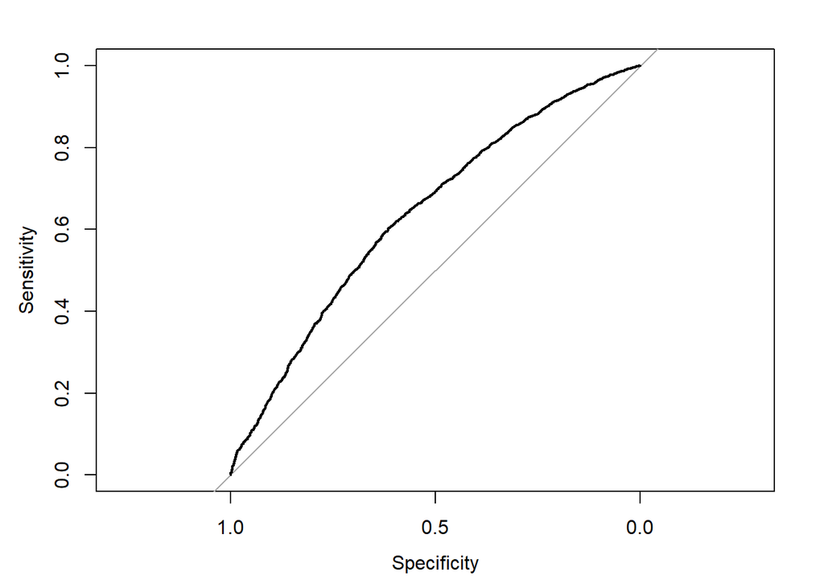

```r
plot(roc_obj)
```

```r
# 5. McFadden's Pseudo-R2
library(pscl)
pR2(model)
```

```
## fitting null model for pseudo-r2
```

```
##       llh   llhNull        G2  McFadden      r2ML      r2CU
## -4.79e+03 -4.98e+03  3.82e+02  3.83e-02  3.31e-02  5.66e-02
```

```r
# 6. Feature Selection / Model Comparison (AIC, BIC)
# AIC and BIC
AIC(model)
```

```
## [1] 9672
```

```r
BIC(model)
```

```
## [1] 9980
```

```r
# 7. Deviance
model$deviance
```

```
## [1] 9588
```

We find that while the overall accuracy is high (84%), the model performs poorly in identifying the negative class (specificity is very low). The ROC-AUC value suggests a fair discrimination ability. The McFadden’s Pseudo-R2 value is 0.0383 (which is relatively low), suggesting that the model does not explain much of the variability in the response variable. The AIC and BIC values are relatively high, suggesting that the model could be further improved.

### Adjusting the Cut-off Threshold

We use the ROC curve to find the optimal cut-off value that balances sensitivity and specificity.

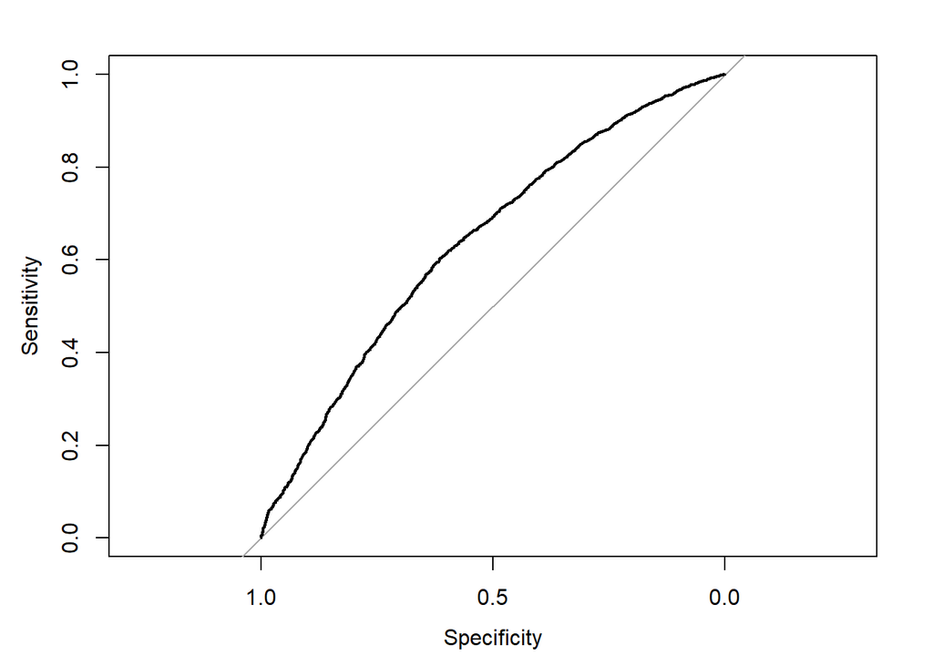

```r
predicted_probabilities <- predict(model, newdata = df_clean, type = "response")

library(pROC)
roc_obj <- roc(df_clean$hrs_stream_binary, predicted_probabilities)

# Plot the ROC curve
plot(roc_obj)
```

```r
# Find the optimal cut-off
optimal_cutoff <- coords(roc_obj, "best", ret = "threshold", best.method = "closest.topleft")
optimal_cutoff
```

```
##   threshold
## 1     0.839
```

```r
optimal_cutoff <- optimal_cutoff[1]  # Extract the cut-off value
```

The optimal cut-off threshold identified from the ROC curve is approximately 0.839. This means that using a cut-off value of 0.839 instead of the default 0.5 can potentially provide a better balance between sensitivity (true positive rate) and specificity (true negative rate) for our logistic regression model.

### Apply the Optimal Cut-off

```r
# Generate predicted classes using the optimal cut-off
optimal_cutoff_value <- optimal_cutoff[1, "threshold"] # Ensure we're getting the right threshold value
predicted_classes_optimal <- ifelse(predicted_probabilities > optimal_cutoff_value, 1, 0)

# Ensure the vectors are of the same length
cat("Length of predicted probabilities: ", length(predicted_probabilities), "\n")
```

```
## Length of predicted probabilities:  11328
```

```r
cat("Length of predicted classes (optimal): ", length(predicted_classes_optimal), "\n")
```

```
## Length of predicted classes (optimal):  11328
```

```r
cat("Length of actual binary outcome: ", length(df_clean$hrs_stream_binary), "\n")
```

```
## Length of actual binary outcome:  11328
```

```r
# Check for NA values in the actual binary outcome
cat("Number of NA values in actual binary outcome: ", sum(is.na(df_clean$hrs_stream_binary)), "\n")
```

```
## Number of NA values in actual binary outcome:  0
```

```r
# Check for NA values in predicted classes
cat("Number of NA values in predicted classes (optimal): ", sum(is.na(predicted_classes_optimal)), "\n")
```

```
## Number of NA values in predicted classes (optimal):  0
```

```r
# Ensure all vectors are of the same length
if (length(predicted_classes_optimal) != length(df_clean$hrs_stream_binary)) {
  stop("Lengths of predicted_classes_optimal and df_clean$hrs_stream_binary do not match.")
}

# Confusion Matrix
conf_matrix_optimal <- table(predicted_classes_optimal, df_clean$hrs_stream_binary)
print(conf_matrix_optimal)
```

```
##
## predicted_classes_optimal    0    1
##                         0 1115 3780
##                         1  700 5733
```

```r
# Calculate performance metrics
accuracy_optimal <- sum(diag(conf_matrix_optimal)) / sum(conf_matrix_optimal)
precision_optimal <- conf_matrix_optimal[2, 2] / (conf_matrix_optimal[2, 2] + conf_matrix_optimal[2, 1])
recall_optimal <- conf_matrix_optimal[2, 2] / (conf_matrix_optimal[2, 2] + conf_matrix_optimal[1, 2])
f1_score_optimal <- 2 * (precision_optimal * recall_optimal) / (precision_optimal + recall_optimal)

# Print the results
cat("Accuracy (optimal cut-off): ", accuracy_optimal, "\n")
```

```
## Accuracy (optimal cut-off):  0.605
```

```r
cat("Precision (optimal cut-off): ", precision_optimal, "\n")
```

```
## Precision (optimal cut-off):  0.891
```

```r
cat("Recall (optimal cut-off): ", recall_optimal, "\n")
```

```
## Recall (optimal cut-off):  0.603
```

```r
cat("F1 Score (optimal cut-off): ", f1_score_optimal, "\n")
```

```
## F1 Score (optimal cut-off):  0.719
```

The model is correct 60.5% of the time, which is moderate but not particularly high. The F1 score provides a balance between precision and recall, indicating a reasonable balance but still suggesting room for improvement.

### Output of the LR model

To enhance the analysis, we recommend employing a random forest model as an alternative to logistic regression.

# Random Forest Classifcication

We will model the mental health outcomes (GAD, SWL, and SPIN) using the ordinarily encoded scores in a classification random forest, as the total scores themselves are discrete and would not work with a regression forest.

```r
df <- df[complete.cases(df$GAD_ord, df$cleaned_whyplay, df$hrs_stream_combined, df$Game,df$Platform, df$earning, df$Gender, df$Age, df$Work,df$Residence), ]


#Random Forest does not allow chr, they have to be factors
df$cleaned_whyplay <- factor(df$cleaned_whyplay)
df$Game <- factor(df$Game)
df$Gender <- factor(df$Gender)
df$GAD_ord <- factor(as.character(df$GAD_ord))

#encode as needed
cleaned_whyplay_encoded <- as.integer(factor(df$cleaned_whyplay))
gender_encoded <- as.integer(factor(df$Gender))
game_encoded <- as.integer(factor(df$Game))

df$cleaned_whyplay_encoded <- cleaned_whyplay_encoded
df$gender_encoded <- gender_encoded
df$game_encoded <- game_encoded
#str(df)
```

### GAD

As we can see below, the GAD scores are very imbalanced. We first balance the data using a combination of oversampling (SMOTE) and randomly under sampling the majority class.

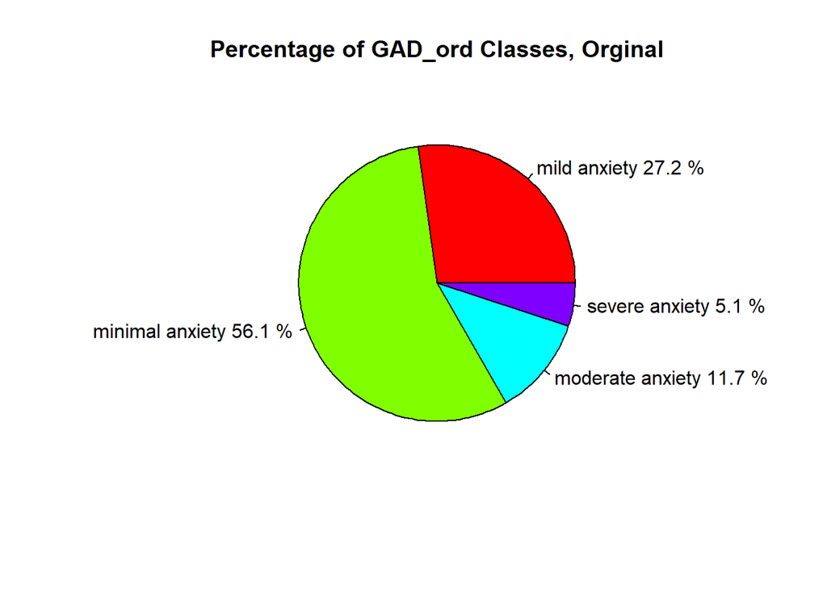

```r
class_counts <- table(df$GAD_ord)

class_percentages <- prop.table(class_counts) * 100

# Pie chart of class percentages
pie(class_counts,
    main = "Percentage of GAD_ord Classes, Orginal",
    col = rainbow(length(class_counts)),
    labels = paste(names(class_counts), round(class_percentages, 1), "%"))
```

```r
# Ensure the target variable GAD_ord is a factor


df$GAD_ord <- as.factor(df$GAD_ord)

# Select the relevant predictors and the target variable
predictors <- df[, c("cleaned_whyplay_encoded", "Hours", "streams", "game_encoded", "gender_encoded", "Age")]
target <- df$GAD_ord

# Apply SMOTE
set.seed(123) # For reproducibility
smote_result <- SMOTE(X = predictors, target = target, K = 1, dup_size = 4)

# Combine the SMOTE result into a new data frame
smote_data <- data.frame(smote_result$data)

# Rename the target variable
names(smote_data)[ncol(smote_data)] <- "GAD_ord"

# Ensure the target variable in the new data frame is a factor
smote_data$GAD_ord <- as.factor(smote_data$GAD_ord)

# Verify the distribution of the target variable after SMOTE
#print(table(smote_data$GAD_ord))
```

```r
# Ensure the target variable GAD_ord is a factor
df$GAD_ord <- as.factor(df$GAD_ord)

# Select the relevant predictors and the target variable
predictors <- smote_data[, c("cleaned_whyplay_encoded", "Hours", "streams", "gender_encoded", "game_encoded", "Age")]
target <- smote_data$GAD_ord

# Apply SMOTE
set.seed(123) # For reproducibility
smote_result <- SMOTE(X = predictors, target = target, K = 1, dup_size = 2)

# Combine the SMOTE result into a new data frame
smote_data2 <- data.frame(smote_result$data)

# Rename the target variable
names(smote_data2)[ncol(smote_data)] <- "GAD_ord"

# Ensure the target variable in the new data frame is a factor
smote_data2$GAD_ord <- as.factor(smote_data2$GAD_ord)

# Verify the distribution of the target variable after SMOTE
#print(table(smote_data2$GAD_ord))


class_counts <- table(smote_data2$GAD_ord)

class_percentages <- prop.table(class_counts) * 100

# Pie chart of class percentages
#pie(class_counts,
 #   main = "Percentage of GAD_ord Classes",
 #   col = rainbow(length(class_counts)),
 #   labels = paste(names(class_counts), round(class_percentages, 1), "%"))

#str(smote_data2)
```

```r
#model_bal <- randomForest(GAD_ord ~ cleaned_whyplay_encoded + Hours * streams #,
 #                            data = smote_data2,
 #                            ntree = 1000)

#cat("Accuracy -- bal: ", mean(predict(model_bal) == smote_data2$GAD_ord), #"\n")

#print(model_bal)

#importance(model_bal)
#varImpPlot(model_bal)
```

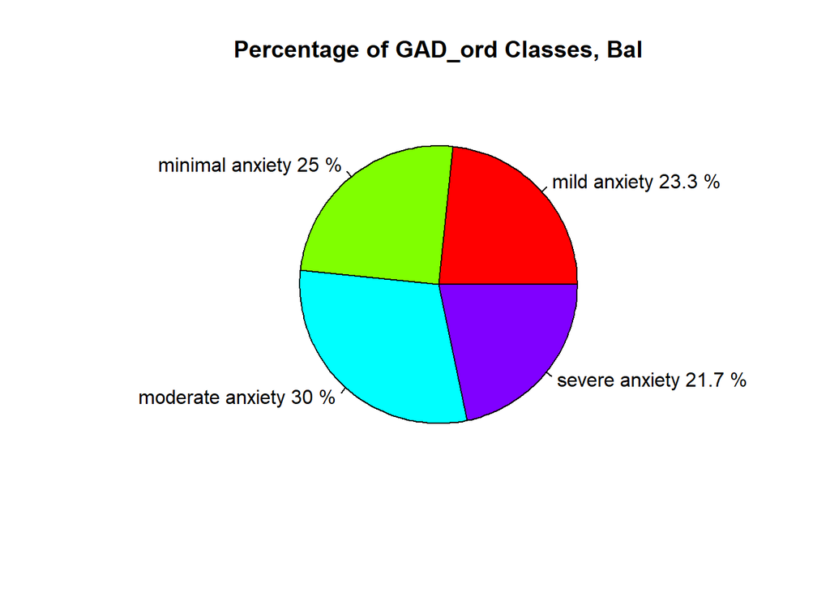

```r
# Check the distribution of the classes
#table(smote_data2$GAD_ord)

# Ensure the "GAD_ord" column is a factor or character
smote_data2$GAD_ord <- as.character(smote_data2$GAD_ord)  # Convert to character if it's a factor

# Now, under-sample the "minimal anxiety" class to 3643
set.seed(123)  # For reproducibility

# Subset the "minimal anxiety" rows and the other classes
minimal_anxiety <- smote_data2[smote_data2$GAD_ord == "minimal anxiety", ]
other_classes <- smote_data2[smote_data2$GAD_ord != "minimal anxiety", ]

# Ensure there are enough rows to sample from the "minimal anxiety" class
if (nrow(minimal_anxiety) >= 3643) {
  minimal_anxiety_undersampled <- minimal_anxiety[sample(1:nrow(minimal_anxiety), 3643), ]
} else {
  stop("Not enough rows in 'minimal anxiety' class to sample 3643.")
}

# Combine the undersampled "minimal anxiety" class with the other classes
df_undersampled <- rbind(minimal_anxiety_undersampled, other_classes)

# Check the new distribution
#table(df_undersampled$GAD_ord)


class_counts <- table(df_undersampled$GAD_ord)

class_percentages <- prop.table(class_counts) * 100

# Pie chart of class percentages
pie(class_counts,
    main = "Percentage of GAD_ord Classes, Bal",
    col = rainbow(length(class_counts)),
    labels = paste(names(class_counts), round(class_percentages, 1), "%"))
```

```r
df_undersampled$GAD_ord <- as.factor(df_undersampled$GAD_ord)
```

During initial modeling, it was apparent the the trees were having trouble distinguishing between the mild and minimal classes. We’ve determined that the high density of data at GAD_T score 5 (the lowest score in the mild class) is causing the model to struggle to identity the boundary between mild and minimal. Mild and minimal will be consolidated into one class to simplify the model.

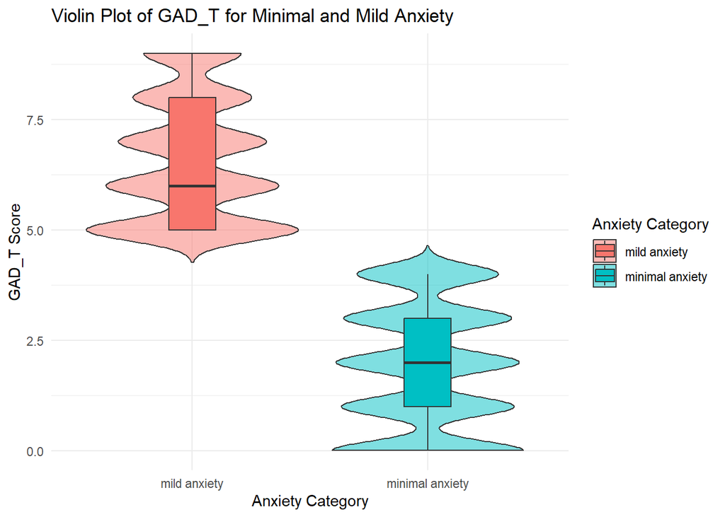

```r
# Violin plot to visualize the distribution with y-axis scaled from 0 to 9
ggplot(minimal_mild, aes(x = GAD_ord, y = GAD_T, fill = GAD_ord)) +
  geom_violin(trim = FALSE, alpha = 0.5) +
  geom_boxplot(width = 0.2, position = position_dodge(0.9)) +
  labs(title = "Violin Plot of GAD_T for Minimal and Mild Anxiety",
       x = "Anxiety Category", y = "GAD_T Score", fill = "Anxiety Category") +
  ylim(0, 9) +
  theme_minimal()
```

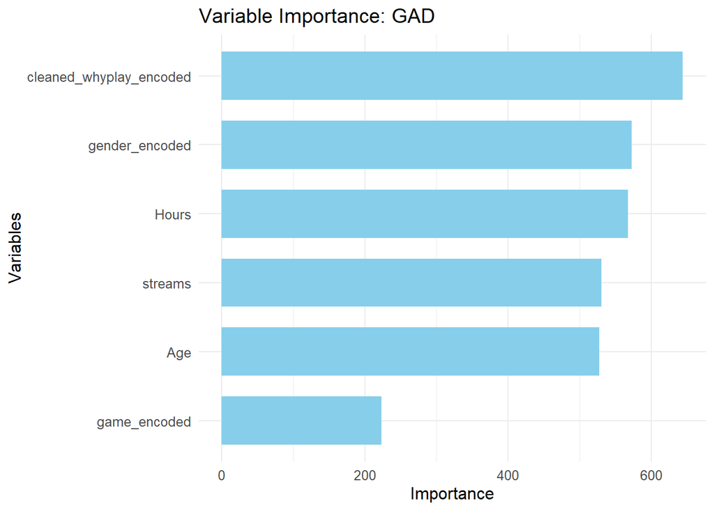

```r
# Consolidate minimal and mild anxiety into "minimal-mild anxiety"
df_undersampled$GAD_ord <- factor(
  ifelse(df_undersampled$GAD_ord %in% c("minimal anxiety", "mild anxiety"),
         "minimal-mild anxiety",
         as.character(df_undersampled$GAD_ord)), # Retain other classes
  levels = c("minimal-mild anxiety", "moderate anxiety", "severe anxiety") # Define desired order
)

# Verify structure
#str(df_undersampled)

#levels(df_undersampled$GAD_ord)


model_bal2 <- randomForest(GAD_ord ~ cleaned_whyplay_encoded + Hours + streams + game_encoded + gender_encoded + Age ,
                             data = df_undersampled,
                             ntree = 3000,
                            mtry = 3,
                            nodesize = 5,
                         importance = TRUE)



#cat("Accuracy -- bal: ", mean(predict(model_bal2) == df_undersampled$GAD_ord), "\n")

#print(model_bal2)

#importance(model_bal2)
#varImpPlot(model_bal2)




# Extract MeanDecreaseAccuracy from the variable importance
var_imp <- importance(model_bal2)
var_imp_df <- data.frame(
  Variable = rownames(var_imp),
  Importance = var_imp[, "MeanDecreaseAccuracy"]
)

# Plot MeanDecreaseAccuracy using ggplot2
ggplot(var_imp_df, aes(x = reorder(Variable, Importance), y = Importance)) +
  geom_bar(stat = "identity", fill = "skyblue", width = 0.7) +
  coord_flip() + # Flip axes for better readability
  theme_minimal() +
  labs(title = "Variable Importance: GAD",
       x = "Variables",
       y = "Importance") +
  theme(text = element_text(size = 12))
```

```r
# Your calculated metrics (use your output here)
metrics <- data.frame(
  Class = c("minimal-mild anxiety", "moderate anxiety", "severe anxiety"),
  Accuracy = c(0.824, 0.952, 0.955),
  Precision = c(0.971, 0.751, 0.854),
  Recall = c(0.824, 0.952, 0.955),
  F1_Score = c(0.891, 0.840, 0.902),
  Overall_Accuracy = c(0.79, 0.79, 0.79)
)

# Format the table using kable
metrics_table <- metrics %>%
  kable(format = "html", digits = 3, align = "lcccccc") %>%
  kable_styling(full_width = F, position = "center") %>%
  column_spec(1, bold = TRUE) %>%
  add_header_above(c(" " = 1, "Metrics" = 5)) %>%  # Adjust header grouping
  row_spec(0, bold = TRUE, color = "white", background = "#4CAF50") %>%
  row_spec(1:nrow(metrics), color = "black", background = "#f2f2f2") %>%
  footnote(
    general = "Table showing model evaluation metrics per class and overall accuracy.",
    general_title = "Note:"
  )

# Print the table
metrics_table
```

| Class | Metrics Accuracy | Metrics Precision | Metrics Recall | Metrics F1_Score | Metrics Overall_Accuracy |
| --- | --- | --- | --- | --- | --- |
| minimal-mild anxiety | 0.824 | 0.971 | 0.824 | 0.891 | 0.79 |
| moderate anxiety | 0.952 | 0.751 | 0.952 | 0.840 | 0.79 |
| severe anxiety | 0.955 | 0.854 | 0.955 | 0.902 | 0.79 |

Note:  
Table showing model evaluation metrics per class and overall accuracy.

### SWL

Once again, we have to balance the data using oversampling and undersampleing.

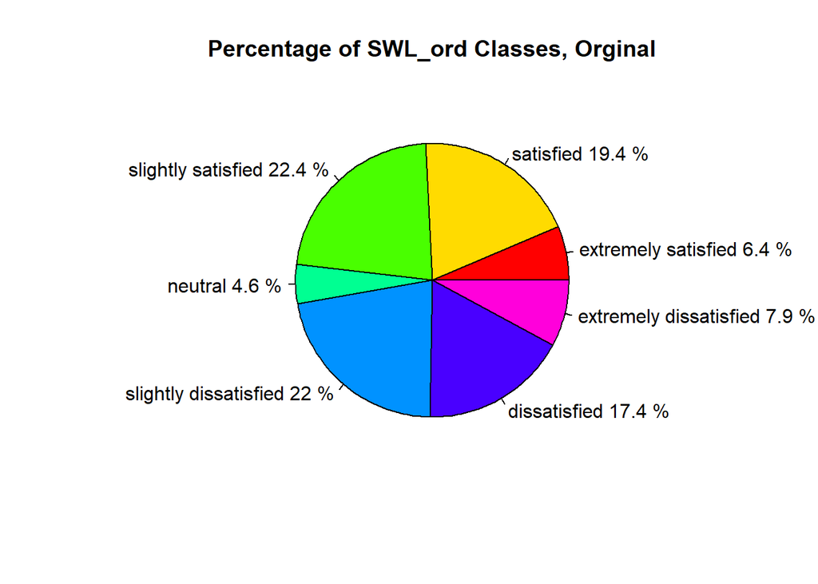

```r
# Ensure the target variable GAD_ord is a factor
df$SWL_ord <- as.factor(df$SWL_ord)
#print(table(df$SWL_ord))

class_counts <- table(df$SWL_ord)

class_percentages <- prop.table(class_counts) * 100

# Pie chart of class percentages
pie(class_counts,
    main = "Percentage of SWL_ord Classes, Orginal",
    col = rainbow(length(class_counts)),
    labels = paste(names(class_counts), round(class_percentages, 1), "%"))
```

```r
# Select the relevant predictors and the target variable
predictors <- df[, c("cleaned_whyplay_encoded", "Hours", "streams", "game_encoded", "gender_encoded", "Age")]
target <- df$SWL_ord

# Apply SMOTE
set.seed(123) # For reproducibility
smote_result <- SMOTE(X = predictors, target = target, K = 1, dup_size = 4)

# Combine the SMOTE result into a new data frame
smote_data <- data.frame(smote_result$data)

# Rename the target variable
names(smote_data)[ncol(smote_data)] <- "SWL_ord"

# Ensure the target variable in the new data frame is a factor
smote_data$SWL_ord <- as.factor(smote_data$SWL_ord)

# Verify the distribution of the target variable after SMOTE
#print(table(smote_data$SWL_ord))

class_counts <- table(smote_data$SWL_ord)



class_percentages <- prop.table(class_counts) * 100


# Pie chart of class percentages
#pie(class_counts,
 #  main = "Percentage of SWL_ord Classes, 1st pass",
  #  col = rainbow(length(class_counts)),
 # labels = paste(names(class_counts), round(class_percentages, 1), "%"))
```

```r
# Select the relevant predictors and the target variable
predictors <- smote_data[, c("cleaned_whyplay_encoded", "Hours", "streams", "game_encoded", "gender_encoded", "Age")]
target <- smote_data$SWL_ord

# Apply SMOTE
set.seed(123) # For reproducibility
smote_result <- SMOTE(X = predictors, target = target, K = 1, dup_size = 4)

# Combine the SMOTE result into a new data frame
smote_data2 <- data.frame(smote_result$data)

# Rename the target variable
names(smote_data2)[ncol(smote_data2)] <- "SWL_ord"

# Ensure the target variable in the new data frame is a factor
smote_data2$SWL_ord <- as.factor(smote_data2$SWL_ord)

# Verify the distribution of the target variable after SMOTE
#print(table(smote_data2$SWL_ord))

class_counts <- table(smote_data2$SWL_ord)



class_percentages <- prop.table(class_counts) * 100


# Pie chart of class percentages
#pie(class_counts,
#   main = "Percentage of SWL_ord Classes, 2nd pass",
#    col = rainbow(length(class_counts)),
#  labels = paste(names(class_counts), round(class_percentages, 1), "%"))
```

```r
# Select the relevant predictors and the target variable
predictors <- smote_data2[, c("cleaned_whyplay_encoded", "Hours", "streams", "game_encoded", "gender_encoded", "Age")]
target <- smote_data2$SWL_ord

#cat("Rows in predictors:", nrow(predictors), "\n")
#cat("Rows in target:", length(target), "\n")

# Apply SMOTE
set.seed(123) # For reproducibility
smote_result <- SMOTE(X = predictors, target = target, K = 1, dup_size = 2)

# Combine the SMOTE result into a new data frame
smote_data3 <- data.frame(smote_result$data)

# Rename the target variable
names(smote_data3)[ncol(smote_data3)] <- "SWL_ord"

# Ensure the target variable in the new data frame is a factor
smote_data3$SWL_ord <- as.factor(smote_data3$SWL_ord)

# Verify the distribution of the target variable after SMOTE
#print(table(smote_data3$SWL_ord))

class_counts <- table(smote_data3$SWL_ord)



class_percentages <- prop.table(class_counts) * 100


# Pie chart of class percentages
#pie(class_counts,
#   main = "Percentage of SWL_ord Classes, 3rd pass",
#    col = rainbow(length(class_counts)),
  #labels = paste(names(class_counts), round(class_percentages, 1), "%"))
```

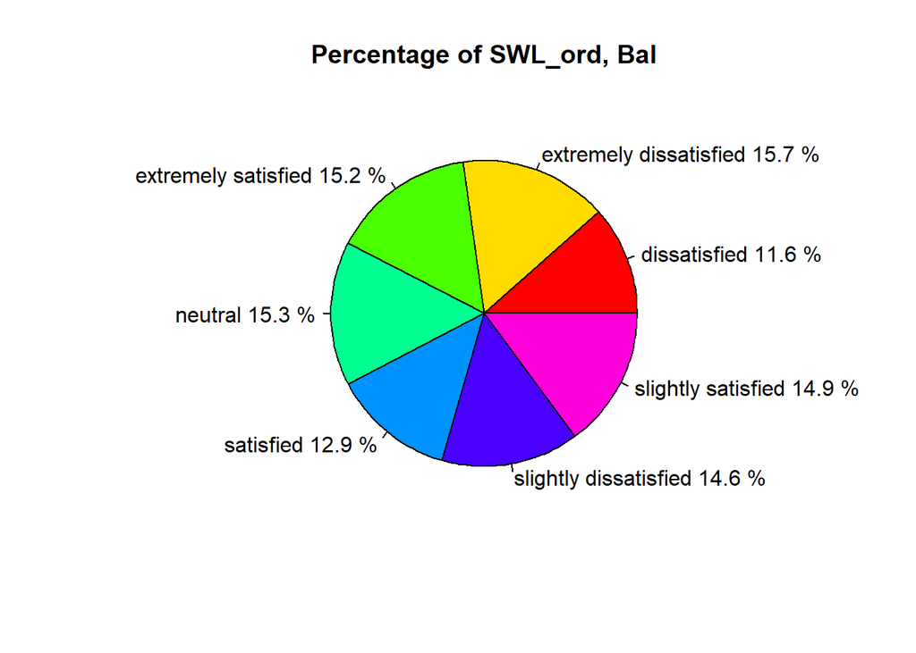

```r
# Ensure the "GAD_ord" column is a factor or character
smote_data3$SWL_ord <- as.character(smote_data3$SWL_ord)  # Convert to character if it's a factor

# Now, under-sample the "minimal anxiety" class to 3643
set.seed(123)  # For reproducibility

# Subset the "minimal anxiety" rows and the other classes
extremely_satisfied <- smote_data3[smote_data3$SWL_ord == "extremely satisfied", ]
other_classes <- smote_data3[smote_data3$SWL_ord != "extremely satisfied", ]


if (nrow(extremely_satisfied) >= 2851) {
  extreme_sat_undersampled <- extremely_satisfied[sample(1:nrow(extremely_satisfied), 2851), ]
} else {
  stop("Not enough rows in 'minimal anxiety' class to sample 2851.")
}

# Combine the undersampled "minimal anxiety" class with the other classes


df_undersampled_swl <- rbind(extreme_sat_undersampled, other_classes)

# Check the new distribution
#table(df_undersampled_swl$SWL_ord)


class_counts <- table(df_undersampled_swl$SWL_ord)

class_percentages <- prop.table(class_counts) * 100

# Pie chart of class percentages
pie(class_counts,
    main = "Percentage of SWL_ord, Bal",
    col = rainbow(length(class_counts)),
    labels = paste(names(class_counts), round(class_percentages, 1), "%"))
```

```r
#df_undersampled_swl$SWL_ord <- as.factor(df_undersampled$SWL_ord)
```

Once again, lack of uniform distribution of the scores leads to the model misclassifying classes when there is skewness towards one of the upper or lower bounds of the next class.

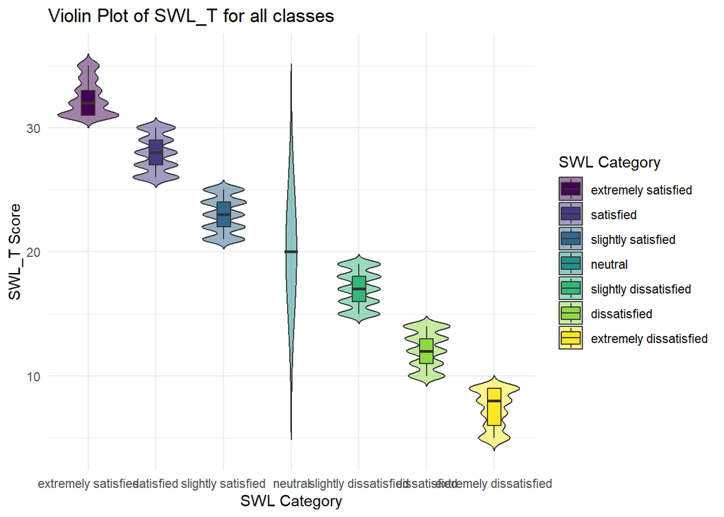

```r
# Violin plot to visualize the distribution with y-axis scaled from 0 to 9
ggplot(minimal_mild, aes(x = SWL_ord, y = SWL_T, fill = SWL_ord)) +
  geom_violin(trim = FALSE, alpha = 0.5) +
  geom_boxplot(width = 0.2, position = position_dodge(0.9)) +
  labs(title = "Violin Plot of SWL_T for all classes",
       x = "SWL Category", y = "SWL_T Score", fill = "SWL Category") +

  theme_minimal()
```

```r
# Consolidate satisfaction and dissatisfaction levels
df_undersampled_swl$SWL_ord <- factor(
  ifelse(df_undersampled_swl$SWL_ord %in% c("satisfied", "slightly satisfied"),
         "sat-slightly_sat",
         ifelse(df_undersampled_swl$SWL_ord %in% c("dissatisfied", "slightly dissatisfied"),
                "dis-slightly_dis",
                as.character(df_undersampled_swl$SWL_ord))), # Retain other classes
  levels = c("extremely satisfied", "sat-slightly_sat", "neutral",
             "dis-slightly_dis", "extremely dissatisfied") # Define desired order
)

# Verify structure
#str(df_undersampled_swl)

# Check the levels
#levels(df_undersampled_swl$SWL_ord)

#table(df_undersampled_swl$SWL_ord)



#ggplot(df_undersampled_swl, aes(x = Hours, fill = SWL_ord)) +
 # geom_density(alpha = 0.5) +
 # labs(title = "Feature Distribution by Class", x = "Hours", y = "Density")
```

Satisfied and slightly satisfied have been consolidated, along with dissatisfied and slightly dissatisfied.

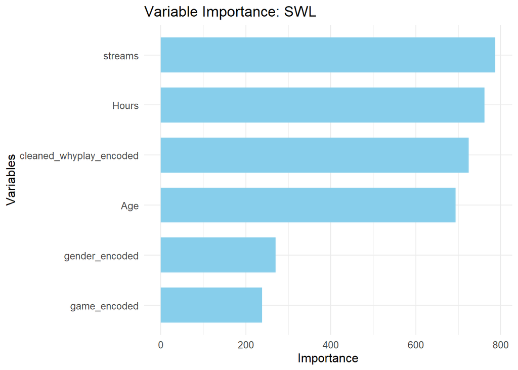

```r
df_undersampled_swl$SWL_ord <- as.factor(df_undersampled_swl$SWL_ord)

model_bal_swl <- randomForest(SWL_ord ~ cleaned_whyplay_encoded + Hours + streams + game_encoded + gender_encoded + Age ,
                             data = df_undersampled_swl,
                            ntree = 3000,
                           mtry = 4,
                        nodesize = 5,
                         importance = TRUE)



#cat("Accuracy -- bal: ", mean(predict(model_bal_swl) == df_undersampled_swl$SWL_ord), "\n")

#print(model_bal_swl)

#importance(model_bal2)
#varImpPlot(model_bal_swl)


# Extract MeanDecreaseAccuracy from the variable importance
var_imp <- importance(model_bal_swl)
var_imp_df <- data.frame(
  Variable = rownames(var_imp),
  Importance = var_imp[, "MeanDecreaseAccuracy"]
)

# Plot MeanDecreaseAccuracy using ggplot2
ggplot(var_imp_df, aes(x = reorder(Variable, Importance), y = Importance)) +
  geom_bar(stat = "identity", fill = "skyblue", width = 0.7) +
  coord_flip() + # Flip axes for better readability
  theme_minimal() +
  labs(title = "Variable Importance: SWL",
       x = "Variables",
       y = "Importance") +
  theme(text = element_text(size = 12))
```

```r
conf_matrix <- matrix(c(
  2065, 346, 108, 234, 98,     # extremely satisfied
  145, 3020, 145, 1731, 180,    # sat-slightly_sat
  92, 352, 2124, 219, 88,       # neutral
  130, 2479, 128, 1969, 216,    # dis-slightly_dis
  165, 476, 149, 400, 1756      # extremely dissatisfied
), nrow = 5, byrow = TRUE)

# Assign class names
colnames(conf_matrix) <- rownames(conf_matrix) <- c("extremely satisfied", "sat-slightly_sat", "neutral", "dis-slightly_dis", "extremely dissatisfied")

# Calculate metrics
accuracy <- diag(conf_matrix) / rowSums(conf_matrix)  # Accuracy for each class
precision <- diag(conf_matrix) / colSums(conf_matrix) # Precision for each class
recall <- diag(conf_matrix) / rowSums(conf_matrix)    # Recall for each class
f1_score <- 2 * (precision * recall) / (precision + recall) # F1-Score for each class

# Overall accuracy (calculated from total confusion matrix)
overall_accuracy <- sum(diag(conf_matrix)) / sum(conf_matrix)

# Create a data frame with the metrics
metrics <- data.frame(
  Class = c("extremely satisfied", "sat-slightly_sat", "neutral", "dis-slightly_dis", "extremely dissatisfied"),
  Accuracy = round(accuracy, 3),
  Precision = round(precision, 3),
  Recall = round(recall, 3),
  F1_Score = round(f1_score, 3),
  Overall_Accuracy = round(rep(overall_accuracy, 5), 3)  # Replicate overall accuracy for each class row
)

# Format the table using kable
metrics_table <- metrics %>%
  kable(format = "html", digits = 3, align = "lcccccc") %>%
  kable_styling(full_width = F, position = "center") %>%
  column_spec(1, bold = TRUE) %>%
  add_header_above(c(" " = 1, "Metrics" = 5, " " = 1)) %>%  # This correctly defines the header with 7 columns
  row_spec(0, bold = TRUE, color = "white", background = "#4CAF50") %>%
  row_spec(1:nrow(metrics), color = "black", background = "#f2f2f2") %>%
  footnote(
    general = "Table showing model evaluation metrics per class and overall accuracy.",
    general_title = "Note:"
  )

# Print the table
metrics_table
```

|  | Metrics Class | Metrics Accuracy | Metrics Precision | Metrics Recall | Metrics F1_Score | Overall_Accuracy |
| --- | --- | --- | --- | --- | --- | --- |
| extremely satisfied | extremely satisfied | 0.724 | 0.795 | 0.724 | 0.758 | 0.581 |
| sat-slightly_sat | sat-slightly_sat | 0.578 | 0.453 | 0.578 | 0.508 | 0.581 |
| neutral | neutral | 0.739 | 0.800 | 0.739 | 0.768 | 0.581 |
| dis-slightly_dis | dis-slightly_dis | 0.400 | 0.432 | 0.400 | 0.416 | 0.581 |
| extremely dissatisfied | extremely dissatisfied | 0.596 | 0.751 | 0.596 | 0.665 | 0.581 |

Note:  
Table showing model evaluation metrics per class and overall accuracy.

The model demonstrates solid performance for “Extremely Satisfied” and “Neutral” with high accuracy, precision, and recall, while struggling with “Dis-Slightly Dis” and “Sat-Slightly Satisfied,” where precision and recall are low. Overall accuracy is 0.581, suggesting misclassification issues, though the model works reasonably well on more distinct classes like “Extremely Satisfied,” with pros in clarity for certain groups but cons in handling less distinct ones.

```r
# Assuming `balanced_data` is your dataset
#set.seed(123)  # For reproducibility
#trainIndex <- createDataPartition(df_undersampled_swl$SWL_ord, p = 0.8, list = FALSE)
#train_data <- df_undersampled_swl[trainIndex, ]
#test_data <- df_undersampled_swl[-trainIndex, ]
#test_data$SWL_ord <- as.factor(test_data$SWL_ord)

grid <- expand.grid(
  mtry = c(2, 4, 6),
  splitrule = "gini",
  min.node.size = c(3, 5, 7, 9)
)

#control <- trainControl(
#  method = "cv",          # Cross-validation
#  number = 5,             # Number of folds
#  verboseIter = TRUE      # Display training progress
#)


# Train the Random Forest model
#rf_model <- train(
#  SWL_ord ~ cleaned_whyplay_encoded + Hours + streams + game_encoded + gender_encoded + Age,
#  data = train_data,
#  method = "ranger",         # Using ranger implementation for efficiency
#  trControl = control,
#  tuneGrid = grid
#)

# Display the best parameters and results
#print(rf_model)


# Predictions on the test dataset
#predictions <- predict(rf_model, newdata = test_data)
```

### SPIN

Again, we begin by balacing the classes of SPIN

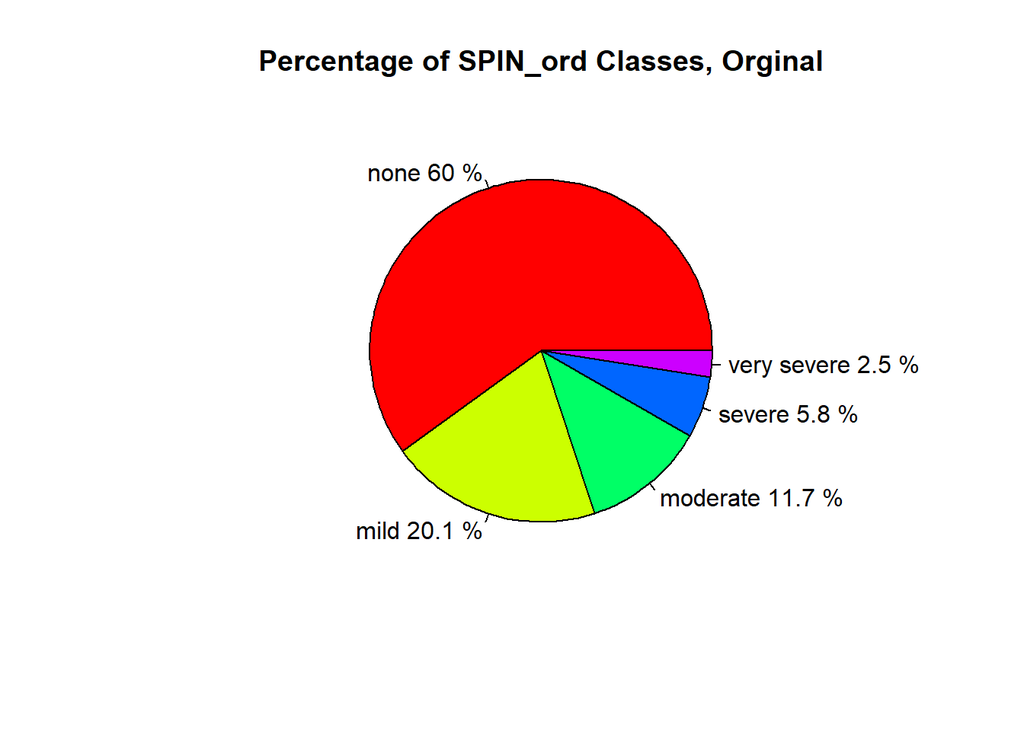

```r
df$SPIN_ord <- as.factor(df$SPIN_ord)
#print(table(df$SPIN_ord))

class_counts <- table(df$SPIN_ord)

class_percentages <- prop.table(class_counts) * 100

# Pie chart of class percentages
pie(class_counts,
    main = "Percentage of SPIN_ord Classes, Orginal",
    col = rainbow(length(class_counts)),
    labels = paste(names(class_counts), round(class_percentages, 1), "%"))
```

```r
# Select the relevant predictors and the target variable
#predictors <- df[, c("cleaned_whyplay_encoded", "Hours", "streams", "game_encoded", "gender_encoded", "Age")]
#target <- df$SPIN_ord

#cat("Rows in predictors:", nrow(predictors), "\n")
#cat("Rows in target:", length(target), "\n")

#str(predictors)
#str(target)

# Check for any NA values or data inconsistencies
#sum(is.na(predictors))
#sum(is.na(target))

df <- df[!is.na(df$SPIN_ord), ]

#target <- df$SPIN_ord

#sum(is.na(target))

# Apply SMOTE
#set.seed(123) # For reproducibility
#smote_result2 <- SMOTE(X = predictors, target = target, K = 2, dup_size = 1)

# Ensure the target variable GAD_ord is a factor
df$SPIN_ord <- as.factor(df$SPIN_ord)

# Select the relevant predictors and the target variable
predictors <- df[, c("cleaned_whyplay_encoded", "Hours", "streams", "game_encoded", "gender_encoded", "Age")]
target <- df$SPIN_ord

# Apply SMOTE
set.seed(123) # For reproducibility
smote_result <- SMOTE(X = predictors, target = target, K = 1, dup_size = 4)



# Combine the SMOTE result into a new data frame
smote_data_spin1 <- data.frame(smote_result$data)

# Rename the target variable
names(smote_data_spin1)[ncol(smote_data_spin1)] <- "SPIN_ord"

# Ensure the target variable in the new data frame is a factor
smote_data_spin1$SWL_ord <- as.factor(smote_data_spin1$SPIN_ord)

# Verify the distribution of the target variable after SMOTE
#print(table(smote_data_spin1$SPIN_ord))

#str(smote_data_spin1)

class_counts <- table(smote_data_spin1$SPIN_ord)

#print(class_counts)

class_percentages <- prop.table(class_counts) * 100


# Pie chart of class percentages
#pie(class_counts,
#   main = "Percentage of SPIN_ord Classes, 1st pass",
#    col = rainbow(length(class_counts)),
#  labels = paste(names(class_counts), round(class_percentages, 1), "%"))
```

```r
# Ensure the target variable GAD_ord is a factor
smote_data_spin1$SPIN_ord <- as.factor(smote_data_spin1$SPIN_ord)

# Select the relevant predictors and the target variable
predictors <- smote_data_spin1[, c("cleaned_whyplay_encoded", "Hours", "streams", "game_encoded", "gender_encoded", "Age")]
target <- smote_data_spin1$SPIN_ord

# Apply SMOTE
set.seed(123) # For reproducibility
smote_result <- SMOTE(X = predictors, target = target, K = 1, dup_size = 2)



# Combine the SMOTE result into a new data frame
smote_data_spin2 <- data.frame(smote_result$data)

# Rename the target variable
names(smote_data_spin2)[ncol(smote_data_spin2)] <- "SPIN_ord"

# Ensure the target variable in the new data frame is a factor
smote_data_spin2$SWL_ord <- as.factor(smote_data_spin2$SPIN_ord)

# Verify the distribution of the target variable after SMOTE
#print(table(smote_data_spin2$SPIN_ord))

#str(smote_data_spin2)

class_counts <- table(smote_data_spin2$SPIN_ord)

#print(class_counts)

class_percentages <- prop.table(class_counts) * 100


# Pie chart of class percentages
#pie(class_counts,
 #  main = "Percentage of SPIN_ord Classes, 2nd pass",
 #   col = rainbow(length(class_counts)),
  #labels = paste(names(class_counts), round(class_percentages, 1), "%"))
```

```r
# Ensure the target variable GAD_ord is a factor
smote_data_spin2$SPIN_ord <- as.factor(smote_data_spin2$SPIN_ord)

# Select the relevant predictors and the target variable
predictors <- smote_data_spin2[, c("cleaned_whyplay_encoded", "Hours", "streams", "game_encoded", "gender_encoded", "Age")]
target <- smote_data_spin2$SPIN_ord

# Apply SMOTE
set.seed(123) # For reproducibility
smote_result <- SMOTE(X = predictors, target = target, K = 1, dup_size = 1)



# Combine the SMOTE result into a new data frame
smote_data_spin3 <- data.frame(smote_result$data)

# Rename the target variable
names(smote_data_spin3)[ncol(smote_data_spin3)] <- "SPIN_ord"

# Ensure the target variable in the new data frame is a factor
smote_data_spin3$SWL_ord <- as.factor(smote_data_spin3$SPIN_ord)

# Verify the distribution of the target variable after SMOTE
#print(table(smote_data_spin3$SPIN_ord))

#str(smote_data_spin3)

class_counts <- table(smote_data_spin3$SPIN_ord)

#print(class_counts)

class_percentages <- prop.table(class_counts) * 100


# Pie chart of class percentages
#pie(class_counts,
  # main = "Percentage of SPIN_ord Classes, 3rd pass",
  #  col = rainbow(length(class_counts)),
 # labels = paste(names(class_counts), round(class_percentages, 1), "%"))
```

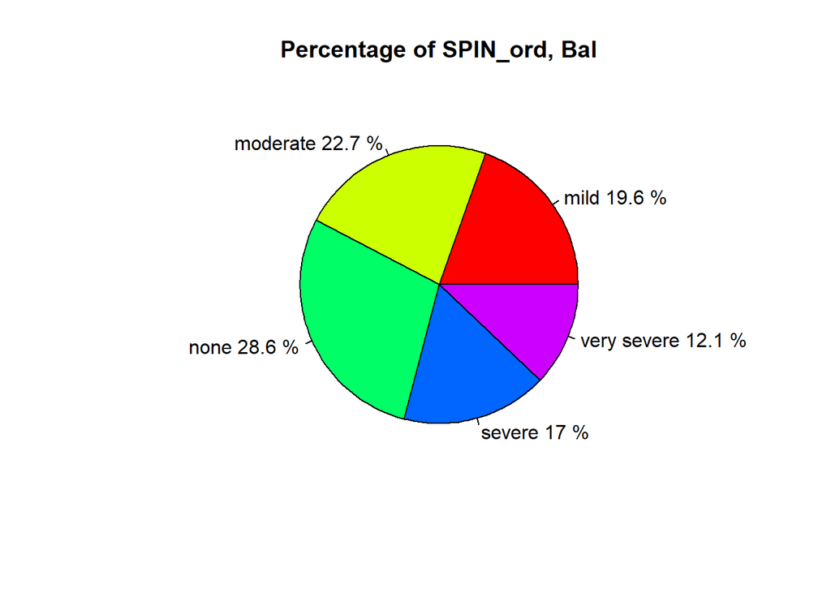

```r
# Ensure the "GAD_ord" column is a factor or character
smote_data_spin3$SPIN_ord <- as.character(smote_data_spin3$SPIN_ord)  # Convert to character if it's a factor

# Now, under-sample the "minimal anxiety" class to 3643
set.seed(123)  # For reproducibility

# Subset the "minimal anxiety" rows and the other classes
extremely_satisfied <- smote_data_spin3[smote_data_spin3$SPIN_ord == "none", ]
other_classes <- smote_data_spin3[smote_data_spin3$SPIN_ord != "none", ]


if (nrow(extremely_satisfied) >= 3500) {
  extreme_sat_undersampled <- extremely_satisfied[sample(1:nrow(extremely_satisfied), 3500), ]
} else {
  stop("Not enough rows in 'minimal anxiety' class to sample 2851.")
}

# Combine the undersampled "minimal anxiety" class with the other classes


df_undersampled_spin <- rbind(extreme_sat_undersampled, other_classes)

# Check the new distribution
#table(df_undersampled_spin$SPIN_ord)


class_counts <- table(df_undersampled_spin$SPIN_ord)

class_percentages <- prop.table(class_counts) * 100

# Pie chart of class percentages
pie(class_counts,
    main = "Percentage of SPIN_ord, Bal",
    col = rainbow(length(class_counts)),
    labels = paste(names(class_counts), round(class_percentages, 1), "%"))
```